# proGram

```
Group Name: DataBusters
Course: BUDT704
Section: 0501
Date: 5th December 2022

Group Members:
1. Tania Sinhasan
2. Lekhya Reddy Mudda
3. Rohan Tangadpelli
4. Yannan Zhu
5. Chetana Shinde
6. Vishnu Kothagadi
```

# Project Report

## Introduction

Instagram has **1.39 billion** users who spend an average of 11.7 hours using the app per month. And nearly **two-thirds** (62.3%) of them use the app to follow or research brands and products.

Which means that there are a myriad of influencers aggressively competing with each other to get the attention of brands with their content.

Apart from "Cristiano Ronaldo" who made around 85 million dollars in 2021 just from the brand deals on instagram, there is a rise in a LOT of micro and mini influencers who collectively have the same amount of reach.

That brings us to the question of how do growing brands with lower marketing budgets choose the right influencer to effectively meet their marketing goals?

```
                    That's what we tried to solve, with the help of Data Analytics.
```

### What are we trying to achive?

We are trying to generate an optimum quality score for micro and mini influencers to reduce adverse selection. To find this quality score we need to first understand how a users activites on instagram affect their reach and engagement. To break it down further we need to answer a few questions :

1. How can a advertiser reach out to small instagram influencers and find a right match for their specific requirment? How do we quantify this match?
2. What is the best posting time to maximize an influencer's quality score?
3. What locations around the globe should the influencers and businesses target that would ensure higher reach and engagement of the instagram posts?
4. How does a profile with good quality score differ from a profile with bad quality score?
5. Does user's actual engagement completely reflect in the quality score calculated?

### But why do these questions matter?

Okay, but WHY does it matter to answer these questions?

Because:

On an average, brands spend 13.8% of overall company revenue on marketing as of 2022. That's about 5% growth since 2011.

Small business and start-ups don't have enough budget to invest in excessive marketing and advertising. So it becomes pivotal to ensure every penny of their tight-budget marketing expeditures are being effective enough. Which implies that they need a number to quantify and compare different influencers so that they know whom to choose.

Using our analysis of influencers and quality score, small business and startup's can select an influencer to represent their brand. This analysed quality score will also consider if that influencer's content matches with the brand requirment. For example, if a brand is looking to promote its new release handbag, the generated quality score will be highest for the fashion influencer who scores high on all the other considered metrics. This will ensure that enagaging with that particular influencer will help with brand reach and grow.

Lastly,

Brands can't spend a whole day stalking each influencer to decide if they are the 'right fit' for an upcoming campaign.

```
                                We instead leverage the power of data.
```

And that means using various metrics pertaining to an influncer 'quality' and reach of an influencer, to aid in our analysis.

### About the dataset:

The dataset has has been imported from Kaggle, one of the largest online repositories for data. The dataset is a compilation of 3 individual csv files corresponding to various instagram profiles, their corresponding posts and locations of those users resulting in 44 columns in total.

All data was scraped from Instagram's website in 2019 (most recent)

The data was collected via Selenium, using many AWS EC2s and stored in Postresql, all code base Python.

### About our project

Choice for Heavier Grading on Data Processing or Data Analysis Our project is more focused on Data processing, therefore we would like to be more heavily graded on that.

But why data processing?

The original dataset has been scraped from around 42 million posts of about 4.5 million profiles on Instagram, of about 12.9 GB in size. The dataset is a combination of 3 csv files, overall having millions of rows and 44 columns in total. Such large dataset coupled with random noise implies a whole of processing required before analysis.

Following tasks justify the strenuous processing required for this dataset:

1. To meet the requirements of the business case, we filter out micro and mini influencers on Instagram, i.e., only those profiles with a follower count of 1000 to 100000, from about 40 million rows.
2. Cleaned all 3 csv files including handling null values, attribute selection, sampling the rows and customizing the columns.
3. Using primary keys, we match all 3 csv files, i.e., to match each profile with corresponding post, and match each post with corresponding location.
4. In addition, we had to formulate 13 metrics individually that most likely contribute to an influencer’s engagement and reach, as per latest research.

NOTE: 3 datasets (csv files) and 2 excel files have to be inputted in the folder name: proGram_src before running the code.

Link to 3 Data sets: Posts: https://www.kaggle.com/datasets/shmalex/instagram-dataset?select=instagram_posts.csv

Locations: https://www.kaggle.com/datasets/shmalex/instagram-dataset?select=instagram_locations.csv

Profiles: https://www.kaggle.com/datasets/shmalex/instagram-dataset?select=instagram_profiles.csv

Link to 2 excel files: Weightage for metrics: https://docs.google.com/spreadsheets/d/1-E33MACICemuo0re-e7dm3qfJ5_VhV-f/edit?usp=share_link&amp;ouid=113881538259178554976&amp;rtpof=true&amp;sd=true

Number of hashtags score: https://drive.google.com/file/d/1Qmhvktuae8nbzsQRrxLlEvS8q1QhS9Gz/view?usp=share_link

```python
import pandas as pd
import numpy as np
import random
import re
from datetime import datetime
from dateutil.relativedelta import relativedelta
```

## Data Processing

### 1. Data Extraction and Cleaning

Since, the datasets are very big and cannot be loaded completely in python with ease, we have taken a random sample of 100,000 Instagram Profiles from the profiles file.

Furthermore, we have filtered the Instagram Posts dataset by mapping the data using profile id with the sampled out profiles.

#### Process of Data Extraction and Cleaning:

- Instagram Profiles
  - To clean data from the sampled 100,000 dataset of profiles, we first dropp the cts column which is not required to determine the quality score.
  - Then, we drop profiles which have null values in the columns - sid, profile_id and profile_name. These columns are important for mapping to the other files and help us identify the user.
  - Since, our requirement focuses on catering to only mini and micro influencers on instagram, which is determined by the range of their followers, we filter out these influencer profiles with the help of column "followers". We will only take profiles which have followers in the range of 1000 to 100000.
  - We will convert profile_id column to integer64 type (as it is a long int)
  - We will convert followers, followings and n_posts (no of posts) to integer for further mathematical caluclations

```python
## Import data for instagram profiles file and sample random 100,000 profiles

filename_profiles = r"proGram_src\instagram_profiles.csv"

# Get total number of profiles in the file
total_num_profiles = sum(1 for line in open(filename_profiles, encoding="utf8")) - 1 # Total rows in original file
print (f"Total number of profiles in the dataset: {total_num_profiles}")

# Randomly skip rows from file to generate a sample of 100,000 profiles
random.seed(33)
sample_size = 100000                                                                 # Desired sample size
skip = sorted(random.sample(range(1,total_num_profiles+1), total_num_profiles-sample_size))
profiles_sample = pd.read_csv(filename_profiles, skiprows=skip, sep='\t')

# Get total number of profile sampled
print (f"Total number of profiles sampled: {profiles_sample.shape[0]}")

# Display fetched dataset
profiles_sample.head(10)
```

```
Total number of profiles in the dataset: 4509879
Total number of profiles sampled: 99995
```

|  | sid | profile_id | profile_name | firstname_lastname | description | following | followers | n_posts | url | cts | is_business_account |
| --- | --- | --- | --- | --- | --- | --- | --- | --- | --- | --- | --- |
| 0 | 4184468 | 8.559205e+09 | maxime_grauls | Maxime💕 | NaN | NaN | NaN | NaN | NaN | 2019-08-01 14:40:41.458 -0400 | NaN |
| 1 | 4184565 | 2.731852e+08 | amyncz | Amy Czeschin | Love me some Jesus, my hubby (high school swee... | 326.0 | 694.0 | 2294.0 | www.glory-photography.com | 2019-08-01 14:45:35.485 -0400 | False |
| 2 | 4184651 | 2.031493e+09 | gabeblooomfield | Gabe Bloomfield | @rushskatepark @mitsuyocrew #rushskatepark #... | 586.0 | 1149.0 | 188.0 | m.youtube.com/watch?v=DUG2SuP2z4Q | 2019-08-01 14:51:37.873 -0400 | True |
| 3 | 4184681 | 8.097728e+09 | swarmclothing | S W A R M • C L O T H I N G | NaN | NaN | NaN | NaN | NaN | 2019-08-01 14:54:26.476 -0400 | NaN |
| 4 | 4184744 | 1.737882e+09 | polinairgasheva | Полина Ергашева | NaN | NaN | NaN | NaN | NaN | 2019-08-01 14:57:44.566 -0400 | NaN |
| 5 | 4184714 | 5.651218e+09 | ripper.manson | Slavko Obrenović | I'm just a Tim Burtons character in real life.... | 50.0 | 224.0 | 50.0 | NaN | 2019-08-01 14:56:26.610 -0400 | True |
| 6 | 4184890 | 9.052505e+08 | rafampo | Rafael Prado | NaN | NaN | NaN | NaN | NaN | 2019-08-01 15:09:48.243 -0400 | NaN |
| 7 | 4184879 | 1.990379e+09 | garageroasted | Garage Coffee | NaN | NaN | NaN | NaN | NaN | 2019-08-01 15:08:52.351 -0400 | NaN |
| 8 | 4184881 | 2.855756e+08 | andy.monaghan | Andy Monaghan | Travel lover\nPrincipal dancer with @mbnewadve... | 445.0 | 3204.0 | 295.0 | new-adventures.net/romeo-juliet | 2019-08-01 15:08:54.324 -0400 | False |
| 9 | 4184926 | 5.055912e+08 | karenxparsons | KP | 🏋🏝🤸🏻‍♀️🥂🍾 | 968.0 | 352.0 | 384.0 | NaN | 2019-08-01 15:12:33.168 -0400 | True |

```python
## Clean data for instagram profiles

# Drop column cts as it is not required
profiles_sample.drop(columns=['cts'], axis=1, inplace=True)

# Filter rows where sid, profile_id and profile_name is not null
profiles_sample = profiles_sample.dropna(subset=["sid", "profile_id", "profile_name"])

# Filter mino and micro influencer profiles (min followers=1000 and max followers=100000)
min_followers = 1000
max_followers = 100000
profiles_sample = profiles_sample[(profiles_sample.followers > min_followers) & (profiles_sample.followers < max_followers)]

# Convert profile_id column to integer64
profiles_sample["profile_id"] = profiles_sample["profile_id"].astype('int64')

# Convert followers, followings and no of posts to integer
profiles_sample["following"] = profiles_sample["following"].astype(int)
profiles_sample["followers"] = profiles_sample["followers"].astype(int)
profiles_sample["n_posts"] = profiles_sample["n_posts"].astype(int)

# Get total number of profiles after cleaning
no_of_profiles_sample = profiles_sample.shape[0]
print (f"Number of profiles after cleaning: {no_of_profiles_sample}")

# Display final sample of profiles after cleaning
profiles_sample.head(10)
```

```
Number of profiles after cleaning: 18253
```

|  | sid | profile_id | profile_name | firstname_lastname | description | following | followers | n_posts | url | is_business_account |
| --- | --- | --- | --- | --- | --- | --- | --- | --- | --- | --- |
| 2 | 4184651 | 2031492798 | gabeblooomfield | Gabe Bloomfield | @rushskatepark @mitsuyocrew #rushskatepark #... | 586 | 1149 | 188 | m.youtube.com/watch?v=DUG2SuP2z4Q | True |
| 8 | 4184881 | 285575633 | andy.monaghan | Andy Monaghan | Travel lover\nPrincipal dancer with @mbnewadve... | 445 | 3204 | 295 | new-adventures.net/romeo-juliet | False |
| 11 | 4185027 | 222243163 | thestreethearts | streethearts | Artsy things | 2793 | 1509 | 1302 | streethearts.net | False |
| 12 | 4185032 | 3547777346 | snezhkabeauty | Косметолог Ботокс Ресниц | 🎓Дипломированный специалист\n🔻Делаю Красиво бе... | 786 | 1857 | 436 | mssg.me/snezhkolamres | True |
| 17 | 4185129 | 8693568724 | comfortlaser | Лазерная эпиляция Москва | 👸Косметолог, омоложение, лечение акне\n⚜️Лучши... | 44 | 2108 | 284 | api.whatsapp.com/send?phone=79778709053 | True |
| 22 | 4185403 | 346840779 | maisiebrizz | MaisieBrizzolara | Can you tell I like to travel? 📍London. Philos... | 1363 | 1719 | 267 | youtu.be/qsGdkeHLfzM | True |
| 23 | 4185460 | 504400186 | chazzacolly | C🌼 | @alexkent101 | 1113 | 1334 | 24 | NaN | False |
| 34 | 4185739 | 363921172 | calebpence8 | Caleb Pence | •Sallisaw OK\n•Racing is my passion \n•Philipp... | 1869 | 5127 | 108 | NaN | False |
| 40 | 4185932 | 1767139989 | nicolas.jurasco | Nicolas jurasco Dubai | 00971557772888 & whatsapp | 4331 | 1851 | 2623 | gmail.com | False |
| 41 | 4185943 | 22140056 | giorgiasenazencoach | Giorgia Sena | Procuradora Federal \nDoutoranda Un... | 1805 | 1872 | 2643 | soundcloud.com/giorgiasena | False |

- Instagram Locations
  - All the locations of this dataset are loaded but only the required columns are considered. Since we do not need information about website, slug, and other unrelated attributes for generating quality score, we will only take the following columns while loading the dataset: 'sid', 'id', 'name', 'street', 'zip', 'city', 'region', 'cd', 'dir_city_name', 'dir_city_slug', 'dir_country_id', 'dir_country_name', 'lat', 'lng'.
  - To clean data of the entire dataset of locations, we will drop the locations which have null values in the columns sid, id, name and cd (country code). These columns are important for mapping to other files and help us identify the location.

```python
## Import data from instagram locations file

filename_locations = r"proGram_src\instagram_locations.csv"

# Create list of columns required for import
columns_req = ['sid', 'id', 'name', 'street', 'zip', 'city', 'region', 'cd', 'dir_city_name', 'dir_city_slug', 'dir_country_id', 'dir_country_name', 'lat', 'lng']

# Load data
locations_dataset = pd.read_csv(filename_locations, usecols=columns_req, sep='\t')

# Get total number of locations in the file
print (f"Total number of locations in dataset: {locations_dataset.shape[0]}")

# Display fetched dataset
locations_dataset.head(10)
```

```
Total number of locations in dataset: 1022658
```

|  | sid | id | name | street | zip | city | region | cd | dir_city_name | dir_city_slug | dir_country_id | dir_country_name | lat | lng |
| --- | --- | --- | --- | --- | --- | --- | --- | --- | --- | --- | --- | --- | --- | --- |
| 0 | 719981 | 110296492939207 | Playa de Daimuz - Valencia, España | NaN | NaN | NaN | NaN | NaN | NaN | NaN | NaN | NaN | -0.139475 | 38.974391 |
| 1 | 719983 | 274391278 | Nová Vieska | NaN | NaN | Nová Vieska | NaN | SK | Kis-Újfalu | kis-ujfalu | SK | Slovakia | 18.466667 | 47.866667 |
| 2 | 719985 | 148885595789195 | Everest Today | Himalayas | +977 | Kathmandu, Nepal | NaN | NP | Pasupati | pasupati | NP | Nepal | 85.330150 | 27.701960 |
| 3 | 719987 | 263258277 | BULAC - Bibliothèque universitaire des langues... | 65, rue des Grands-Moulins | 75013 | Paris, France | NaN | FR | 13ème Arrondissement Paris | 13eme-arrondissement-paris | FR | France | 2.375995 | 48.827240 |
| 4 | 326443 | 406147529857708 | ABC Cable Networks Group | 3800 W Alameda Ave | 91505 | Burbank, California | NaN | US | NaN | NaN | NaN | NaN | -118.341864 | 34.153265 |
| 5 | 326440 | 242403516699715 | The Lakes at Discovery Bay | NaN | NaN | NaN | NaN | NaN | NaN | NaN | NaN | NaN | -121.621549 | 37.925412 |
| 6 | 719988 | 1651686855080719 | Tampines, Singapore | Tampines | 529941 | Singapore | NaN | SG | NaN | NaN | NaN | NaN | 103.949729 | 1.355203 |
| 7 | 719992 | 240487083 | Sittano’s Bar & Restaurant | Shop R03 Westfield Penrith, Level 1 / Riley St... | 2750 | Penrith, New South Wales | NaN | AU | Penrith | penrith | AU | Australia | 150.694367 | -33.751031 |
| 8 | 719996 | 750669435108256 | วัดท่าซุง อุทัยธานี | 3212 | 61000 | Nam Soem, Uthai Thani, Thailand | NaN | TH | NaN | NaN | NaN | NaN | 100.073586 | 15.329776 |
| 9 | 719998 | 223283275 | Cine Atlas | Hatanpään valtatie 1 | 33100 | Tampere, Finland | NaN | FI | NaN | NaN | NaN | NaN | 23.766263 | 61.495690 |

```python
## Clean data for instagram locations

# Filter rows where sid, id, name, and country (cd) is not null
locations_sample = locations_dataset.dropna(subset=["sid", "id", "name", "cd"])

# Convert profile_id column to integer64
locations_sample["id"] = locations_sample["id"].astype('int64')

# Get total number of locations after cleaning
no_of_locations_sample = locations_sample.shape[0]
print (f"Number of locations after cleaning: {no_of_locations_sample}")

# Display final sample of locations after cleaning
locations_sample.head(10)
```

```
Number of locations after cleaning: 939010
```

|  | sid | id | name | street | zip | city | region | cd | dir_city_name | dir_city_slug | dir_country_id | dir_country_name | lat | lng |
| --- | --- | --- | --- | --- | --- | --- | --- | --- | --- | --- | --- | --- | --- | --- |
| 1 | 719983 | 274391278 | Nová Vieska | NaN | NaN | Nová Vieska | NaN | SK | Kis-Újfalu | kis-ujfalu | SK | Slovakia | 18.466667 | 47.866667 |
| 2 | 719985 | 148885595789195 | Everest Today | Himalayas | +977 | Kathmandu, Nepal | NaN | NP | Pasupati | pasupati | NP | Nepal | 85.330150 | 27.701960 |
| 3 | 719987 | 263258277 | BULAC - Bibliothèque universitaire des langues... | 65, rue des Grands-Moulins | 75013 | Paris, France | NaN | FR | 13ème Arrondissement Paris | 13eme-arrondissement-paris | FR | France | 2.375995 | 48.827240 |
| 4 | 326443 | 406147529857708 | ABC Cable Networks Group | 3800 W Alameda Ave | 91505 | Burbank, California | NaN | US | NaN | NaN | NaN | NaN | -118.341864 | 34.153265 |
| 6 | 719988 | 1651686855080719 | Tampines, Singapore | Tampines | 529941 | Singapore | NaN | SG | NaN | NaN | NaN | NaN | 103.949729 | 1.355203 |
| 7 | 719992 | 240487083 | Sittano’s Bar & Restaurant | Shop R03 Westfield Penrith, Level 1 / Riley St... | 2750 | Penrith, New South Wales | NaN | AU | Penrith | penrith | AU | Australia | 150.694367 | -33.751031 |
| 8 | 719996 | 750669435108256 | วัดท่าซุง อุทัยธานี | 3212 | 61000 | Nam Soem, Uthai Thani, Thailand | NaN | TH | NaN | NaN | NaN | NaN | 100.073586 | 15.329776 |
| 9 | 719998 | 223283275 | Cine Atlas | Hatanpään valtatie 1 | 33100 | Tampere, Finland | NaN | FI | NaN | NaN | NaN | NaN | 23.766263 | 61.495690 |
| 10 | 720000 | 470291196648741 | NKA Makeup | Mario Bravo 849 | NaN | Buenos Aires, Argentina | NaN | AR | NaN | NaN | NaN | NaN | -58.416060 | -34.600030 |
| 11 | 720005 | 1012918773 | Love You To the Moon & Back | 17775 Pleasant Valley Dr | 48044 | Macomb, Michigan | NaN | US | NaN | NaN | NaN | NaN | -82.945289 | 42.666886 |

- Instagram Posts
  - Based on the profiles sampled out, we will filter out posts by matching the profile ids.
  - As the posts dataset is huge, we are implementing the filtration process using chunks while reading the file.
  - To clean the dataset, we will first drop posts which have null value in column sid
  - We will convert the columns profile_id and location_id columns to integer64 (as they are long int)
  - We will convert number of likes and number of comments columns to integer for further mathematical operations
  - We will convert cts column to date and time format as this column represents the date and time the post was put on the profile. We need to apply date time operations on this column in further analysis.

```python
## Import data from instagram posts file

filename_posts = r"proGram_src\instagram_posts.csv"

# Sample posts dataset by filtering out posts based on sample profiles by matching profile ids
chunksize = 100000       # we will import file in chunks as data is too huge
i = 1
for chunk in pd.read_csv(filename_posts, sep='\t', low_memory=False, chunksize=chunksize):
        posts = chunk[chunk["profile_id"].isin(profiles_sample["profile_id"])]
        if i == 1:
            posts_sample = posts
        else:
            posts_sample = pd.concat([posts_sample, posts])
        i = i+1

# Get total number of posts fetched from the file based on profiles sample
print (f"Total number of posts fetched from file based on profiles sample: {posts_sample.shape[0]}")

# Display fetched posts
posts_sample.head(10)
```

```
Total number of posts fetched from file based on profiles sample: 191406
```

|  | sid | sid_profile | post_id | profile_id | location_id | cts | post_type | description | numbr_likes | number_comments |
| --- | --- | --- | --- | --- | --- | --- | --- | --- | --- | --- |
| 3355 | 15131935 | 3471655 | Bw4XLtMga2j | 3.582981e+08 | 5.484382e+08 | 2019-04-30 15:03:13.000 | 1 | Tampa Police Honor Guard was able to join the ... | 206.0 | 5.0 |
| 5633 | 27386281 | 3398819 | BgkKMt4hAW7 | 2.955287e+09 | 1.012855e+09 | 2018-03-21 01:22:38.000 | 1 | Доброе утро, красотки 💃🏻\nУ нас отличная новос... | 302.0 | 13983.0 |
| 5662 | 27386295 | 3398819 | BqLfnHeBp_g | 2.955287e+09 | 1.012855e+09 | 2018-11-15 00:42:40.000 | 1 | Доброе утро, друзья!\nМы запускаем грандиозную... | 113.0 | 3.0 |
| 5663 | 27386298 | 3398819 | Bnm3n-xgvVO | 2.955287e+09 | 1.012855e+09 | 2018-09-12 03:18:44.000 | 2 | Всем привет🌷\nСегодня самый важный день для на... | 63.0 | 4.0 |
| 8355 | 28379377 | 3343709 | BwtdZAKgk7O | 9.160016e+09 | 1.027062e+09 | 2019-04-26 09:25:48.000 | 1 | Костюм джинсовый тройка 💕💕💕 3350₽\nРазмер 42, ... | 16.0 | 0.0 |
| 8495 | 28379529 | 360593 | BxeOfsXB1aR | 2.458462e+08 | 4.508292e+07 | 2019-05-15 07:58:26.000 | 1 | Let me introduce you to a gentleman who is a t... | 455.0 | 21.0 |
| 10286 | 28381506 | 3917753 | BkJGDAxnSIV | 4.040536e+08 | 1.565835e+14 | 2018-06-18 00:12:26.000 | 1 | The rose shaped gelato only lasted a minute un... | 371.0 | 46.0 |
| 12795 | 28384187 | 3497910 | BQ5QtXODQLr | 3.553708e+08 | 2.591453e+08 | 2017-02-24 13:41:16.000 | 2 | Another chill one from the other day @georgeyy... | 108.0 | 0.0 |
| 16378 | 28387842 | 158967 | BM8kcByhyxV | 3.427072e+08 | 2.616589e+08 | 2016-11-18 10:25:48.000 | 1 | Kurtka @goodlookin_pl 💙 #girl #blonde #blogger... | 973.0 | 48.0 |
| 16624 | 28388081 | 1025022 | BxsfxxRjuK4 | 1.291047e+09 | 1.698223e+15 | 2019-05-20 20:59:46.000 | 2 | #roadtrip #filmmakerslife #travelphotography #... | 20.0 | 3.0 |

```python
## Clean data for instagram posts

# Filter rows where sid is not null
posts_sample = posts_sample.dropna(subset=["sid"])

# Convert profile_id and location_id columns to integer64
posts_sample["profile_id"] = posts_sample["profile_id"].astype('Int64')
posts_sample["location_id"] = posts_sample["location_id"].fillna(0)
posts_sample["location_id"] = posts_sample["location_id"].astype('Int64')

# Convert number of likes and number of comments columns to integer
posts_sample["numbr_likes"] = posts_sample["numbr_likes"].astype(int)
posts_sample["number_comments"] = posts_sample["number_comments"].astype(int)

# Convert cts to date time format
posts_sample['cts'] = pd.to_datetime(posts_sample['cts'])

# Get total number of posts after cleaning
no_of_posts_sample = posts_sample.shape[0]
print (f"Number of posts after cleaning: {no_of_posts_sample}")

# Display final sample of posts after cleaning
posts_sample.head(10)
```

```
Number of posts after cleaning: 191406
```

|  | sid | sid_profile | post_id | profile_id | location_id | cts | post_type | description | numbr_likes | number_comments |
| --- | --- | --- | --- | --- | --- | --- | --- | --- | --- | --- |
| 3355 | 15131935 | 3471655 | Bw4XLtMga2j | 358298091 | 548438207 | 2019-04-30 15:03:13 | 1 | Tampa Police Honor Guard was able to join the ... | 206 | 5 |
| 5633 | 27386281 | 3398819 | BgkKMt4hAW7 | 2955286544 | 1012854533 | 2018-03-21 01:22:38 | 1 | Доброе утро, красотки 💃🏻\nУ нас отличная новос... | 302 | 13983 |
| 5662 | 27386295 | 3398819 | BqLfnHeBp_g | 2955286544 | 1012854533 | 2018-11-15 00:42:40 | 1 | Доброе утро, друзья!\nМы запускаем грандиозную... | 113 | 3 |
| 5663 | 27386298 | 3398819 | Bnm3n-xgvVO | 2955286544 | 1012854533 | 2018-09-12 03:18:44 | 2 | Всем привет🌷\nСегодня самый важный день для на... | 63 | 4 |
| 8355 | 28379377 | 3343709 | BwtdZAKgk7O | 9160016422 | 1027061897 | 2019-04-26 09:25:48 | 1 | Костюм джинсовый тройка 💕💕💕 3350₽\nРазмер 42, ... | 16 | 0 |
| 8495 | 28379529 | 360593 | BxeOfsXB1aR | 245846154 | 45082915 | 2019-05-15 07:58:26 | 1 | Let me introduce you to a gentleman who is a t... | 455 | 21 |
| 10286 | 28381506 | 3917753 | BkJGDAxnSIV | 404053613 | 156583481415876 | 2018-06-18 00:12:26 | 1 | The rose shaped gelato only lasted a minute un... | 371 | 46 |
| 12795 | 28384187 | 3497910 | BQ5QtXODQLr | 355370762 | 259145290 | 2017-02-24 13:41:16 | 2 | Another chill one from the other day @georgeyy... | 108 | 0 |
| 16378 | 28387842 | 158967 | BM8kcByhyxV | 342707208 | 261658876 | 2016-11-18 10:25:48 | 1 | Kurtka @goodlookin_pl 💙 #girl #blonde #blogger... | 973 | 48 |
| 16624 | 28388081 | 1025022 | BxsfxxRjuK4 | 1291046529 | 1698222890407446 | 2019-05-20 20:59:46 | 2 | #roadtrip #filmmakerslife #travelphotography #... | 20 | 3 |

### 2. Implementing Calculations for Various Metrics

For the analysis purpose, we need to define various metrics that need to be formulated using the existing columns. These metrics will further be used to determine the quality score for each influencer.

We broadly divide those metrics into 2 categories:

1. Static metrics: Static metrics have a fixed value and can contribute in generating a constant score. These can be directly derived from the dataset through calculations without any external interference.
2. Dynamic metrics: Dynamic metrics depend on keyword matching, where the keyword is provided by the advertisers. These need external input i.e. keyword for their calculations. A keyword is a phrase provided by advertisers to find the right match for the marketing of their product.

In the below analysis, we have taken the keyword as "travel" to generate all the various metrics. "Travel" keyword could be provided by businesses such as airlines, travel agencies and so on. These businesses would need instagram influencers with content related to "travel". The dynamic metrics help us in quantifying this match.

```python
keyword = 'travel'
```

For each profile, we will calculate a total 13 metrics and create a new dataframe with these values.

#### Metrics 1 : Total Number of Followers of the Profile

From the instagram profiles dataset, we get the total number of followers of each profile under the column "followers". The more the followers of a profile, the better would be its quality score, since the product advertisement would reach more people/target audience.

> followers = followers column of instagram profiles

#### Metrics 2: Total Number of Posts (Based on Profiles data)

From the instagram profiles dataset, we will get the total number of posts of each profile under the column "n_posts". The more the posts on a profile, the better would be its quality score as it shows high activity of the inflencer.

> n_posts = n_posts column of instagram profiles

_Note: This value (in instagram profiles) dataset in different when compared to the actual number of posts in the posts dataset for the user. We will consider n*posts for this metrics, but for other calculations we will take number of posts from the posts dataset.*

```python
## Metrics 1: Total Number of Followers
## Metrics 2: Total Number of Posts (Based on profiles data)

df_quality_score = pd.DataFrame(profiles_sample[["profile_id", "followers", "n_posts"]])
df_quality_score.set_index('profile_id', inplace=True)

# Get Total number of posts of user by counting number of rows for each user in posts sample
posts_by_users = posts_sample.groupby(by=['profile_id'])['sid'].count().rename('total_posts', inplace=True)
df_quality_score = df_quality_score.merge(posts_by_users, left_index=True, right_index=True)


df_quality_score.head(10)
```

| profile_id | followers | n_posts | total_posts |
| --- | --- | --- | --- |
| 2031492798 | 1149 | 188 | 12 |
| 285575633 | 3204 | 295 | 13 |
| 222243163 | 1509 | 1302 | 13 |
| 3547777346 | 1857 | 436 | 20 |
| 8693568724 | 2108 | 284 | 18 |
| 346840779 | 1719 | 267 | 17 |
| 504400186 | 1334 | 24 | 12 |
| 363921172 | 5127 | 108 | 12 |
| 1767139989 | 1851 | 2623 | 14 |
| 22140056 | 1872 | 2643 | 14 |

#### Metrics 3: Engagement Score of profile

From instagram posts dataset, we will calculate the sum of numbers of likes and number of comments for all posts of each user and divide this value by total number of followers of the profile. This metrics quantifies the engagement of users with these influencers and better engagement would mean a better quality score.

> eng_score = total number of likes + total number of comments (of all posts of user) / total number of followers

```python
## Metrics 3: Engagement Score of each profile/user


## Engagement Score = Number of likes + Number of comments (of all posts of the user) / Total number of followers of user

# Get Total number of likes & comments by summation of all numbr_likes and number_comments columns for each user
sum_cols = ["numbr_likes", "number_comments"]
posts_by_users = posts_sample.groupby(by=['profile_id'])[sum_cols].sum()
df_quality_score = df_quality_score.merge(posts_by_users, left_index=True, right_index=True)


# Calculate Engagement Score for all users
df_quality_score["eng_score"] = ((df_quality_score['numbr_likes'] + df_quality_score['number_comments'])
                                 /df_quality_score['followers']).round(2)


# Display Engagament metrics
df_quality_score.head(10)
```

| profile_id | followers | n_posts | total_posts | numbr_likes | number_comments | eng_score |
| --- | --- | --- | --- | --- | --- | --- |
| 2031492798 | 1149 | 188 | 12 | 1398 | 71 | 1.28 |
| 285575633 | 3204 | 295 | 13 | 4834 | 102 | 1.54 |
| 222243163 | 1509 | 1302 | 13 | 338 | 13 | 0.23 |
| 3547777346 | 1857 | 436 | 20 | 673 | 370 | 0.56 |
| 8693568724 | 2108 | 284 | 18 | 377 | 20 | 0.19 |
| 346840779 | 1719 | 267 | 17 | 3761 | 506 | 2.48 |
| 504400186 | 1334 | 24 | 12 | 1060 | 37 | 0.82 |
| 363921172 | 5127 | 108 | 12 | 4454 | 24 | 0.87 |
| 1767139989 | 1851 | 2623 | 14 | 510 | 4 | 0.28 |
| 22140056 | 1872 | 2643 | 14 | 375 | 33 | 0.22 |

#### Metrics 4: Recent Engagement Score of profile

From instagram posts dataset, we will first get the most recent posts of the profile (upto 10) by sorting the posts based on column cts in the descending order (newest would be first) for each profile. Then we will calculate the engagement score for these recent posts only. We will calculate the sum of numbers of likes and number of comments for all posts of each user and divide this value by total number of followers of the profile. This metrics quantifies the recent engagement of users with these influencers and better recent engagement would mean a better quality score.

> eng_score_rec = total number of likes + total number of comments (of recent 10 posts of user) / total number of followers

*Note: If last post was made before 2018 (a year before the dataset was collected, we will consider recent engagement value for user as 0 since the user has become inactive)*

```python
## Metrics 4: Recent Engagement Rate of each profile/user

## Calculating Engagement Score for recent 10 posts of the user
## If last post was made before 2018 --> Recent Engagement Score = 0

# Get most recent 10 posts for each user and create new posts sample
posts_sample_temp = posts_sample.copy()
posts_sample_temp.sort_values(by=['profile_id','cts'], ascending=[True,False], inplace=True)
posts_sample_temp = posts_sample_temp.groupby('profile_id').head(10)


## For the most recent 10 posts we will calculate:
## Recent Engagement Score = Number of likes + Number of comments (of all posts of the user) / Total number of followers of user

# Get Total number of likes & comments by summation of all numbr_likes and number_comments columns for each user
sum_cols = ["numbr_likes", "number_comments"]
posts_by_users = posts_sample_temp.groupby(by=['profile_id'])[sum_cols].sum()
df_quality_score = df_quality_score.merge(posts_by_users, left_index=True, right_index=True, suffixes=['', '_rec'])

# Calculate Engagement Score for all users
df_quality_score["eng_score_rec"] = ((df_quality_score['numbr_likes_rec'] + df_quality_score['number_comments_rec'])
                                     /df_quality_score['followers']).round(2)


## Check if last post was made before 2018
year_threshold = 2018

# Create dummy variable for users whose recent post was before 2018 (value=0) or not (value=1)
posts_sample_temp = posts_sample_temp.groupby('profile_id').head(1)
posts_sample_temp['recent_post_before_2018'] = posts_sample_temp['cts'].map(lambda x: 0 if x.year < year_threshold else 1)
df_quality_score = df_quality_score.merge(posts_sample_temp[['profile_id', 'recent_post_before_2018']],
                                          left_index=True, right_on='profile_id').set_index('profile_id')

# Make Engagement Score = 0 if user's recent post was before 2018
df_quality_score["eng_score_rec"] = df_quality_score["eng_score_rec"] * df_quality_score['recent_post_before_2018']


# Display Recent Engagement metrics
df_quality_score.head(10)
```

| profile_id | followers | n_posts | total_posts | numbr_likes | number_comments | eng_score | numbr_likes_rec | number_comments_rec | eng_score_rec | recent_post_before_2018 |
| --- | --- | --- | --- | --- | --- | --- | --- | --- | --- | --- |
| 2031492798 | 1149 | 188 | 12 | 1398 | 71 | 1.28 | 1169 | 64 | 1.07 | 1 |
| 285575633 | 3204 | 295 | 13 | 4834 | 102 | 1.54 | 4178 | 88 | 1.33 | 1 |
| 222243163 | 1509 | 1302 | 13 | 338 | 13 | 0.23 | 218 | 7 | 0.15 | 1 |
| 3547777346 | 1857 | 436 | 20 | 673 | 370 | 0.56 | 338 | 282 | 0.33 | 1 |
| 8693568724 | 2108 | 284 | 18 | 377 | 20 | 0.19 | 212 | 13 | 0.11 | 1 |
| 346840779 | 1719 | 267 | 17 | 3761 | 506 | 2.48 | 2295 | 369 | 1.55 | 1 |
| 504400186 | 1334 | 24 | 12 | 1060 | 37 | 0.82 | 933 | 33 | 0.72 | 1 |
| 363921172 | 5127 | 108 | 12 | 4454 | 24 | 0.87 | 3119 | 23 | 0.61 | 1 |
| 1767139989 | 1851 | 2623 | 14 | 510 | 4 | 0.28 | 361 | 2 | 0.20 | 1 |
| 22140056 | 1872 | 2643 | 14 | 375 | 33 | 0.22 | 291 | 19 | 0.17 | 1 |

#### Metrics 5: Average percentage of increase in engagement score (Growth)

From instagram posts dataset, we will map the followers for each post with the followers in profiles dataset. Then we will calculate the engagement score for each post (using the original formula). Then we will sort the posts based on ascending order of cts (datetime stamp) for each profile. We will calculate the percentage increase of engagement in consecutive posts and get the average percentage increase for each user. This metrics quantifies the growth of engagement of for influencers and better the growth would mean a better quality score.

> perc_inc_eng_score = average of percentage increase of engagement score in consecutive posts for a user (asceding order of timestamp of posts)

*Note: If average percentage increase is negative, will consider this metrics value as 0.*

```python
## Metrics 5: Average percentage of increase in engagement score (Growth)

# Get a copy of posts samples
posts_sample_temp = posts_sample.copy()

## For every post we will calculate:
## Engagement Score = Number of likes + Number of comments (of all posts of the user) / Total number of followers of user

# Get Total number of followers of user in posts sample dataset
posts_sample_temp = posts_sample_temp.merge(profiles_sample[["profile_id", "followers"]], left_on="profile_id", right_on="profile_id", how="left")

# Get Engagement rate for each post
posts_sample_temp["eng_score"] = ((posts_sample_temp["numbr_likes"] + posts_sample_temp["number_comments"])
                                  / posts_sample_temp["followers"])

# Sort posts by users and timestamp (recent first)
posts_sample_temp.sort_values(by=['profile_id','cts'], ascending=[True,True], inplace=True)

# Get percentage of increase in engagement score for consecutive posts for user
posts_sample_temp["perc_inc_eng_score"] = posts_sample_temp.groupby('profile_id')["eng_score"].pct_change() * 100

# To handle np.inf values, we will make np.inf or -np.inf as np.nan (not to be considered for average perc increase)
posts_sample_temp["perc_inc_eng_score"] = posts_sample_temp["perc_inc_eng_score"].replace([np.inf, -np.inf], np.nan)

# Get average of percentage of increase in engagement score for all posts for each user
posts_sample_temp = posts_sample_temp.groupby('profile_id')["perc_inc_eng_score"].mean().round(2)

# Consider average of percentage increase as 0 if Nan
posts_sample_temp = posts_sample_temp.fillna(0)

# If average of percentage of increase in eng score is negative then we will consider this score as 0
posts_sample_temp = posts_sample_temp.mask((posts_sample_temp < 0), 0)
df_quality_score = df_quality_score.merge(posts_sample_temp, left_index=True, right_index=True)

# Display metrics
df_quality_score.head(20)
```

| profile_id | followers | n_posts | total_posts | numbr_likes | number_comments | eng_score | numbr_likes_rec | number_comments_rec | eng_score_rec | recent_post_before_2018 | perc_inc_eng_score |
| --- | --- | --- | --- | --- | --- | --- | --- | --- | --- | --- | --- |
| 2031492798 | 1149 | 188 | 12 | 1398 | 71 | 1.28 | 1169 | 64 | 1.07 | 1 | 2.24 |
| 285575633 | 3204 | 295 | 13 | 4834 | 102 | 1.54 | 4178 | 88 | 1.33 | 1 | 24.45 |
| 222243163 | 1509 | 1302 | 13 | 338 | 13 | 0.23 | 218 | 7 | 0.15 | 1 | 8.50 |
| 3547777346 | 1857 | 436 | 20 | 673 | 370 | 0.56 | 338 | 282 | 0.33 | 1 | 38.93 |
| 8693568724 | 2108 | 284 | 18 | 377 | 20 | 0.19 | 212 | 13 | 0.11 | 1 | 2.23 |
| 346840779 | 1719 | 267 | 17 | 3761 | 506 | 2.48 | 2295 | 369 | 1.55 | 1 | 32.58 |
| 504400186 | 1334 | 24 | 12 | 1060 | 37 | 0.82 | 933 | 33 | 0.72 | 1 | 13.32 |
| 363921172 | 5127 | 108 | 12 | 4454 | 24 | 0.87 | 3119 | 23 | 0.61 | 1 | 0.00 |
| 1767139989 | 1851 | 2623 | 14 | 510 | 4 | 0.28 | 361 | 2 | 0.20 | 1 | 84.65 |
| 22140056 | 1872 | 2643 | 14 | 375 | 33 | 0.22 | 291 | 19 | 0.17 | 1 | 7.55 |
| 194267213 | 1489 | 497 | 15 | 2145 | 42 | 1.47 | 1604 | 33 | 1.10 | 1 | 27.68 |
| 44200763 | 2597 | 3264 | 13 | 682 | 10 | 0.27 | 532 | 10 | 0.21 | 1 | 20.61 |
| 346156619 | 1135 | 391 | 14 | 1198 | 12 | 1.07 | 789 | 7 | 0.70 | 1 | 0.00 |
| 5973285 | 8347 | 490 | 16 | 4309 | 474 | 0.57 | 2643 | 276 | 0.35 | 1 | 37.30 |
| 22489717 | 2724 | 5279 | 15 | 1016 | 61 | 0.40 | 610 | 37 | 0.24 | 1 | 16.24 |
| 1418566770 | 3018 | 123 | 15 | 2736 | 53 | 0.92 | 1742 | 21 | 0.58 | 1 | 3.19 |
| 1637675 | 2402 | 424 | 19 | 2845 | 139 | 1.24 | 1410 | 95 | 0.63 | 1 | 4.79 |
| 2228444959 | 1667 | 212 | 13 | 1764 | 33 | 1.08 | 1370 | 20 | 0.83 | 1 | 10.29 |
| 19860790 | 1363 | 177 | 13 | 693 | 49 | 0.54 | 472 | 37 | 0.37 | 1 | 54.78 |
| 423121505 | 1247 | 152 | 14 | 3640 | 95 | 3.00 | 2645 | 75 | 2.18 | 1 | 5.07 |

#### Metrics 6: Average number of likes per post by Total Followers

We get the average number of likes per post by dividing the total likes of all posts for the user (calculated during engagement score metrics) by the total number of posts of the user. This value is further divided by the total number of followers. This metrics quantifies the average engagement of users for their post and better average engagement would mean a better quality score.

> avg_likes_by_foll = (total number of likes / total number of posts (for each user) ) / total followers

#### Metrics 7: Average number of comments per post by Total Followers

We get the average number of comments per post by dividing the total comments of all posts for the user (calculated during engagement score metrics) by the total number of posts of the user. This value is further divided by the total number of followers. This metrics quantifies the average engagement of users for their post and better average engagement would mean a better quality score.

> avg_com_by_foll = (total number of comments / total number of posts (for each user) ) / total followers

```python
## Metrics 6: Average no. of likes per post by Total Followers
## Metrics 7: Average no. of comments per post by Total Followers

# Get Average number of likes i.e. (total numbr_likes / total posts for each user) / total followers
df_quality_score['avg_likes_by_foll'] = ((df_quality_score['numbr_likes'] / df_quality_score['total_posts'])/df_quality_score['followers']).round(2)

# Get Average number of comments i.e. (total comments_likes / total posts for each user) / total followers
df_quality_score['avg_com_by_foll'] = ((df_quality_score['number_comments'] / df_quality_score['total_posts'])/df_quality_score['followers']).round(2)

# Display metrics
df_quality_score.head(20)
```

| profile_id | followers | n_posts | total_posts | numbr_likes | number_comments | eng_score | numbr_likes_rec | number_comments_rec | eng_score_rec | recent_post_before_2018 | perc_inc_eng_score | avg_likes_by_foll | avg_com_by_foll |
| --- | --- | --- | --- | --- | --- | --- | --- | --- | --- | --- | --- | --- | --- |
| 2031492798 | 1149 | 188 | 12 | 1398 | 71 | 1.28 | 1169 | 64 | 1.07 | 1 | 2.24 | 0.10 | 0.01 |
| 285575633 | 3204 | 295 | 13 | 4834 | 102 | 1.54 | 4178 | 88 | 1.33 | 1 | 24.45 | 0.12 | 0.00 |
| 222243163 | 1509 | 1302 | 13 | 338 | 13 | 0.23 | 218 | 7 | 0.15 | 1 | 8.50 | 0.02 | 0.00 |
| 3547777346 | 1857 | 436 | 20 | 673 | 370 | 0.56 | 338 | 282 | 0.33 | 1 | 38.93 | 0.02 | 0.01 |
| 8693568724 | 2108 | 284 | 18 | 377 | 20 | 0.19 | 212 | 13 | 0.11 | 1 | 2.23 | 0.01 | 0.00 |
| 346840779 | 1719 | 267 | 17 | 3761 | 506 | 2.48 | 2295 | 369 | 1.55 | 1 | 32.58 | 0.13 | 0.02 |
| 504400186 | 1334 | 24 | 12 | 1060 | 37 | 0.82 | 933 | 33 | 0.72 | 1 | 13.32 | 0.07 | 0.00 |
| 363921172 | 5127 | 108 | 12 | 4454 | 24 | 0.87 | 3119 | 23 | 0.61 | 1 | 0.00 | 0.07 | 0.00 |
| 1767139989 | 1851 | 2623 | 14 | 510 | 4 | 0.28 | 361 | 2 | 0.20 | 1 | 84.65 | 0.02 | 0.00 |
| 22140056 | 1872 | 2643 | 14 | 375 | 33 | 0.22 | 291 | 19 | 0.17 | 1 | 7.55 | 0.01 | 0.00 |
| 194267213 | 1489 | 497 | 15 | 2145 | 42 | 1.47 | 1604 | 33 | 1.10 | 1 | 27.68 | 0.10 | 0.00 |
| 44200763 | 2597 | 3264 | 13 | 682 | 10 | 0.27 | 532 | 10 | 0.21 | 1 | 20.61 | 0.02 | 0.00 |
| 346156619 | 1135 | 391 | 14 | 1198 | 12 | 1.07 | 789 | 7 | 0.70 | 1 | 0.00 | 0.08 | 0.00 |
| 5973285 | 8347 | 490 | 16 | 4309 | 474 | 0.57 | 2643 | 276 | 0.35 | 1 | 37.30 | 0.03 | 0.00 |
| 22489717 | 2724 | 5279 | 15 | 1016 | 61 | 0.40 | 610 | 37 | 0.24 | 1 | 16.24 | 0.02 | 0.00 |
| 1418566770 | 3018 | 123 | 15 | 2736 | 53 | 0.92 | 1742 | 21 | 0.58 | 1 | 3.19 | 0.06 | 0.00 |
| 1637675 | 2402 | 424 | 19 | 2845 | 139 | 1.24 | 1410 | 95 | 0.63 | 1 | 4.79 | 0.06 | 0.00 |
| 2228444959 | 1667 | 212 | 13 | 1764 | 33 | 1.08 | 1370 | 20 | 0.83 | 1 | 10.29 | 0.08 | 0.00 |
| 19860790 | 1363 | 177 | 13 | 693 | 49 | 0.54 | 472 | 37 | 0.37 | 1 | 54.78 | 0.04 | 0.00 |
| 423121505 | 1247 | 152 | 14 | 3640 | 95 | 3.00 | 2645 | 75 | 2.18 | 1 | 5.07 | 0.21 | 0.01 |

#### Metrics 8: Hashtag Score - Ideal Number of Hashtags per post

According to: https://later.com/blog/ultimate-guide-to-using-instagram-hashtags/#:~:text=How%20Many%20Instagram%20Hashtags%20Should,up%20to%2030%20per%20post

> hashtag_score = average of hashtag score for all posts of user (hashtag score calculated based on number of hashtags)

```python
## Metrics 8: Hashtag Score - Ideal number of Hashtags per post

## Get number of hashtags used by each user in their posts

# Import file to map number of hashtags vs score to be given to the user
filename_hashtags_score = r"proGram_src\NumberofHashtags_Score.csv"
hashtags_score_dataset = pd.read_csv(filename_hashtags_score, sep=',')

# Display hashtag score mapping with number of hashtags (between min and max column)
hashtags_score_dataset.head(20)
```

|  | Min | Max | Score |
| --- | --- | --- | --- |
| 0 | 0 | 1 | 0 |
| 1 | 1 | 3 | 1 |
| 2 | 3 | 6 | 2 |
| 3 | 6 | 9 | 4 |
| 4 | 9 | 12 | 5 |
| 5 | 12 | 15 | 6 |
| 6 | 15 | 18 | 7 |
| 7 | 18 | 21 | 9 |
| 8 | 21 | 24 | 10 |
| 9 | 24 | 27 | 9 |
| 10 | 27 | 30 | 8 |
| 11 | 30 | 5000 | 0 |

```python
# Get a copy of posts samples with profile_id and description (description is the caption)
posts_sample_temp = posts_sample[['profile_id', 'description']].copy()

# Pattern for matching hashtag
pattern = "[#][\S]*"

# Create new variable to store average number of hashtags per post used by user
posts_sample_temp["no_of_hashtags"] = posts_sample_temp["description"].str.count(pattern, flags=re.IGNORECASE)
posts_sample_temp["hashtag_score"] = 0
for row in hashtags_score_dataset.iterrows():
    posts_sample_temp["hashtag_score"] = np.where(posts_sample_temp["no_of_hashtags"].between(row[1]["Min"],row[1]["Max"]), row[1]["Score"], posts_sample_temp["hashtag_score"])


# Calculate average of hashtag score for each user
posts_sample_temp = posts_sample_temp.groupby('profile_id').mean().round(2)
df_quality_score = df_quality_score.merge(posts_sample_temp['hashtag_score'], left_index=True, right_index=True)

# Display metrics
df_quality_score.head(10)
```

| profile_id | followers | n_posts | total_posts | numbr_likes | number_comments | eng_score | numbr_likes_rec | number_comments_rec | eng_score_rec | recent_post_before_2018 | perc_inc_eng_score | avg_likes_by_foll | avg_com_by_foll | hashtag_score |
| --- | --- | --- | --- | --- | --- | --- | --- | --- | --- | --- | --- | --- | --- | --- |
| 2031492798 | 1149 | 188 | 12 | 1398 | 71 | 1.28 | 1169 | 64 | 1.07 | 1 | 2.24 | 0.10 | 0.01 | 1.17 |
| 285575633 | 3204 | 295 | 13 | 4834 | 102 | 1.54 | 4178 | 88 | 1.33 | 1 | 24.45 | 0.12 | 0.00 | 0.31 |
| 222243163 | 1509 | 1302 | 13 | 338 | 13 | 0.23 | 218 | 7 | 0.15 | 1 | 8.50 | 0.02 | 0.00 | 5.46 |
| 3547777346 | 1857 | 436 | 20 | 673 | 370 | 0.56 | 338 | 282 | 0.33 | 1 | 38.93 | 0.02 | 0.01 | 0.10 |
| 8693568724 | 2108 | 284 | 18 | 377 | 20 | 0.19 | 212 | 13 | 0.11 | 1 | 2.23 | 0.01 | 0.00 | 2.89 |
| 346840779 | 1719 | 267 | 17 | 3761 | 506 | 2.48 | 2295 | 369 | 1.55 | 1 | 32.58 | 0.13 | 0.02 | 0.00 |
| 504400186 | 1334 | 24 | 12 | 1060 | 37 | 0.82 | 933 | 33 | 0.72 | 1 | 13.32 | 0.07 | 0.00 | 0.00 |
| 363921172 | 5127 | 108 | 12 | 4454 | 24 | 0.87 | 3119 | 23 | 0.61 | 1 | 0.00 | 0.07 | 0.00 | 0.00 |
| 1767139989 | 1851 | 2623 | 14 | 510 | 4 | 0.28 | 361 | 2 | 0.20 | 1 | 84.65 | 0.02 | 0.00 | 6.43 |
| 22140056 | 1872 | 2643 | 14 | 375 | 33 | 0.22 | 291 | 19 | 0.17 | 1 | 7.55 | 0.01 | 0.00 | 1.86 |

#### Metrics 9: Keyword match - Profile Bio

From the instagram profiles dataset, we will get the description column (bio) of the profile and check if the keyword is present in the bio. This score would be 1 if keyword is present and 0 if it is not. Having the keyword in the bio represents a better match with the advertiser and hence, it should increase the influencer's quality score.

> bio_with_keyword = 1 if keyword is in bio, 0 if keyword is not in bio

```python
## Metrics 9: Keyword match - Profile Bio

## Get users whose bios have the keyword

# Get a copy of profiles samples with profile_id and description (description is the bio)
profiles_sample_temp = profiles_sample[['profile_id', 'description']].copy().set_index('profile_id')

# Create new variable to mark if user has bio with the keyword (Yes="1", No="0")
profiles_sample_temp["bio_with_keyword"] = profiles_sample_temp["description"].str.contains(keyword, flags=re.IGNORECASE)
profiles_sample_temp["bio_with_keyword"].fillna(False, inplace=True) # If bio is null, then consider match as False
profiles_sample_temp["bio_with_keyword"] = profiles_sample_temp["bio_with_keyword"].astype(int)
df_quality_score = df_quality_score.merge(profiles_sample_temp['bio_with_keyword'], left_index=True, right_index=True)

# Get total number of profiles with keyword in their bios
print(f"Number of profiles with keyword: {keyword} in their bios = {df_quality_score['bio_with_keyword'].sum()}")

# Display metrics
df_quality_score.head(10)
```

```
Number of profiles with keyword: travel in their bios = 511
```

| profile_id | followers | n_posts | total_posts | numbr_likes | number_comments | eng_score | numbr_likes_rec | number_comments_rec | eng_score_rec | recent_post_before_2018 | perc_inc_eng_score | avg_likes_by_foll | avg_com_by_foll | hashtag_score | bio_with_keyword |
| --- | --- | --- | --- | --- | --- | --- | --- | --- | --- | --- | --- | --- | --- | --- | --- |
| 2031492798 | 1149 | 188 | 12 | 1398 | 71 | 1.28 | 1169 | 64 | 1.07 | 1 | 2.24 | 0.10 | 0.01 | 1.17 | 0 |
| 285575633 | 3204 | 295 | 13 | 4834 | 102 | 1.54 | 4178 | 88 | 1.33 | 1 | 24.45 | 0.12 | 0.00 | 0.31 | 1 |
| 222243163 | 1509 | 1302 | 13 | 338 | 13 | 0.23 | 218 | 7 | 0.15 | 1 | 8.50 | 0.02 | 0.00 | 5.46 | 0 |
| 3547777346 | 1857 | 436 | 20 | 673 | 370 | 0.56 | 338 | 282 | 0.33 | 1 | 38.93 | 0.02 | 0.01 | 0.10 | 0 |
| 8693568724 | 2108 | 284 | 18 | 377 | 20 | 0.19 | 212 | 13 | 0.11 | 1 | 2.23 | 0.01 | 0.00 | 2.89 | 0 |
| 346840779 | 1719 | 267 | 17 | 3761 | 506 | 2.48 | 2295 | 369 | 1.55 | 1 | 32.58 | 0.13 | 0.02 | 0.00 | 1 |
| 504400186 | 1334 | 24 | 12 | 1060 | 37 | 0.82 | 933 | 33 | 0.72 | 1 | 13.32 | 0.07 | 0.00 | 0.00 | 0 |
| 363921172 | 5127 | 108 | 12 | 4454 | 24 | 0.87 | 3119 | 23 | 0.61 | 1 | 0.00 | 0.07 | 0.00 | 0.00 | 0 |
| 1767139989 | 1851 | 2623 | 14 | 510 | 4 | 0.28 | 361 | 2 | 0.20 | 1 | 84.65 | 0.02 | 0.00 | 6.43 | 0 |
| 22140056 | 1872 | 2643 | 14 | 375 | 33 | 0.22 | 291 | 19 | 0.17 | 1 | 7.55 | 0.01 | 0.00 | 1.86 | 0 |

#### Metrics 10: Keyword match (number of posts) - in post captions

We will calculate the number of posts of the users that have the keyword present in their description (caption). Higher the number of posts having the keyword, would represent a better match with the advertiser and it should boost the quality score of the influencer.

> posts_with_keyword = number of posts of user with keyword in their caption

Similarly,

#### Metrics 11: Keyword match (number of posts/total posts) - in post captions

We will calculate the ratio between number of posts of the users that have the keyword present in their description (caption) and the total number of posts of the user. Higher the ratio, would represent a better match with the advertiser and it should boost the quality score of the influencer.

> posts_with_keyword_by_total = number of posts of user with keyword in their caption / total posts of the user

```python
## Metrics 10: Keyword match (number of posts) - in post captions
## Metrics 11: Keyword match (number of posts/total posts) - in posts captions

## Get number of posts that have the keyword for each user

# Get a copy of posts samples with profile_id and description (description is the caption)
posts_sample_temp = posts_sample[['profile_id', 'description']].copy()

# Create new variable to store number of posts that have the keyword for each user
posts_sample_temp["posts_with_keyword"] = posts_sample_temp["description"].str.contains(keyword, flags=re.IGNORECASE)
posts_sample_temp["posts_with_keyword"].fillna(False, inplace=True) # If caption is null, then consider match as 0
posts_sample_temp = posts_sample_temp.groupby('profile_id').sum()
posts_sample_temp["posts_with_keyword"] = posts_sample_temp["posts_with_keyword"].astype(int)
df_quality_score = df_quality_score.merge(posts_sample_temp['posts_with_keyword'], left_index=True, right_index=True)

## Get number of posts that have the keyword/total posts for each user
df_quality_score["posts_with_keyword_by_total"] = (df_quality_score['posts_with_keyword'] / df_quality_score['total_posts']).round(2)

# Display metrics
df_quality_score.head(10)
```

| profile_id | followers | n_posts | total_posts | numbr_likes | number_comments | eng_score | numbr_likes_rec | number_comments_rec | eng_score_rec | recent_post_before_2018 | perc_inc_eng_score | avg_likes_by_foll | avg_com_by_foll | hashtag_score | bio_with_keyword | posts_with_keyword | posts_with_keyword_by_total |
| --- | --- | --- | --- | --- | --- | --- | --- | --- | --- | --- | --- | --- | --- | --- | --- | --- | --- |
| 2031492798 | 1149 | 188 | 12 | 1398 | 71 | 1.28 | 1169 | 64 | 1.07 | 1 | 2.24 | 0.10 | 0.01 | 1.17 | 0 | 0 | 0.00 |
| 285575633 | 3204 | 295 | 13 | 4834 | 102 | 1.54 | 4178 | 88 | 1.33 | 1 | 24.45 | 0.12 | 0.00 | 0.31 | 1 | 0 | 0.00 |
| 222243163 | 1509 | 1302 | 13 | 338 | 13 | 0.23 | 218 | 7 | 0.15 | 1 | 8.50 | 0.02 | 0.00 | 5.46 | 0 | 3 | 0.23 |
| 3547777346 | 1857 | 436 | 20 | 673 | 370 | 0.56 | 338 | 282 | 0.33 | 1 | 38.93 | 0.02 | 0.01 | 0.10 | 0 | 0 | 0.00 |
| 8693568724 | 2108 | 284 | 18 | 377 | 20 | 0.19 | 212 | 13 | 0.11 | 1 | 2.23 | 0.01 | 0.00 | 2.89 | 0 | 0 | 0.00 |
| 346840779 | 1719 | 267 | 17 | 3761 | 506 | 2.48 | 2295 | 369 | 1.55 | 1 | 32.58 | 0.13 | 0.02 | 0.00 | 1 | 0 | 0.00 |
| 504400186 | 1334 | 24 | 12 | 1060 | 37 | 0.82 | 933 | 33 | 0.72 | 1 | 13.32 | 0.07 | 0.00 | 0.00 | 0 | 0 | 0.00 |
| 363921172 | 5127 | 108 | 12 | 4454 | 24 | 0.87 | 3119 | 23 | 0.61 | 1 | 0.00 | 0.07 | 0.00 | 0.00 | 0 | 0 | 0.00 |
| 1767139989 | 1851 | 2623 | 14 | 510 | 4 | 0.28 | 361 | 2 | 0.20 | 1 | 84.65 | 0.02 | 0.00 | 6.43 | 0 | 0 | 0.00 |
| 22140056 | 1872 | 2643 | 14 | 375 | 33 | 0.22 | 291 | 19 | 0.17 | 1 | 7.55 | 0.01 | 0.00 | 1.86 | 0 | 0 | 0.00 |

#### Metrics 12: Keyword match - Hashtags

We will calculate the total number of matches of keywords in all the hashtags used by the user in all his/her posts using regular expression. The hashtag can include any other word but it should contain the keyword as a substring to be considered as a match. Higher the number of matches, would represent a better match with the advertiser and it should boost the quality score of the influencer.

> hashtag_with_keyword = number of matches of keywords in hashtags of all posts of the user

```python
## Metrics 12: Keyword match - Hashtags

## Get number of hashtags used by each user in their posts that have the keyword

# Get a copy of posts samples with profile_id and description (description is the caption)
posts_sample_temp = posts_sample[['profile_id', 'description']].copy()

# Pattern for matching hashtag
pattern = "[#][\S]*"+keyword+"[\S]*"

# Create new variable to store number of hashtags used by user
posts_sample_temp["hashtag_with_keyword"] = posts_sample_temp["description"].str.count(pattern, flags=re.IGNORECASE)
posts_sample_temp = posts_sample_temp.groupby('profile_id').sum()
posts_sample_temp["hashtag_with_keyword"] = posts_sample_temp["hashtag_with_keyword"].astype(int)
df_quality_score = df_quality_score.merge(posts_sample_temp['hashtag_with_keyword'], left_index=True, right_index=True)

# Display metrics
df_quality_score.head(10)
```

| profile_id | followers | n_posts | total_posts | numbr_likes | number_comments | eng_score | numbr_likes_rec | number_comments_rec | eng_score_rec | recent_post_before_2018 | perc_inc_eng_score | avg_likes_by_foll | avg_com_by_foll | hashtag_score | bio_with_keyword | posts_with_keyword | posts_with_keyword_by_total | hashtag_with_keyword |
| --- | --- | --- | --- | --- | --- | --- | --- | --- | --- | --- | --- | --- | --- | --- | --- | --- | --- | --- |
| 2031492798 | 1149 | 188 | 12 | 1398 | 71 | 1.28 | 1169 | 64 | 1.07 | 1 | 2.24 | 0.10 | 0.01 | 1.17 | 0 | 0 | 0.00 | 0 |
| 285575633 | 3204 | 295 | 13 | 4834 | 102 | 1.54 | 4178 | 88 | 1.33 | 1 | 24.45 | 0.12 | 0.00 | 0.31 | 1 | 0 | 0.00 | 0 |
| 222243163 | 1509 | 1302 | 13 | 338 | 13 | 0.23 | 218 | 7 | 0.15 | 1 | 8.50 | 0.02 | 0.00 | 5.46 | 0 | 3 | 0.23 | 4 |
| 3547777346 | 1857 | 436 | 20 | 673 | 370 | 0.56 | 338 | 282 | 0.33 | 1 | 38.93 | 0.02 | 0.01 | 0.10 | 0 | 0 | 0.00 | 0 |
| 8693568724 | 2108 | 284 | 18 | 377 | 20 | 0.19 | 212 | 13 | 0.11 | 1 | 2.23 | 0.01 | 0.00 | 2.89 | 0 | 0 | 0.00 | 0 |
| 346840779 | 1719 | 267 | 17 | 3761 | 506 | 2.48 | 2295 | 369 | 1.55 | 1 | 32.58 | 0.13 | 0.02 | 0.00 | 1 | 0 | 0.00 | 0 |
| 504400186 | 1334 | 24 | 12 | 1060 | 37 | 0.82 | 933 | 33 | 0.72 | 1 | 13.32 | 0.07 | 0.00 | 0.00 | 0 | 0 | 0.00 | 0 |
| 363921172 | 5127 | 108 | 12 | 4454 | 24 | 0.87 | 3119 | 23 | 0.61 | 1 | 0.00 | 0.07 | 0.00 | 0.00 | 0 | 0 | 0.00 | 0 |
| 1767139989 | 1851 | 2623 | 14 | 510 | 4 | 0.28 | 361 | 2 | 0.20 | 1 | 84.65 | 0.02 | 0.00 | 6.43 | 0 | 0 | 0.00 | 0 |
| 22140056 | 1872 | 2643 | 14 | 375 | 33 | 0.22 | 291 | 19 | 0.17 | 1 | 7.55 | 0.01 | 0.00 | 1.86 | 0 | 0 | 0.00 | 0 |

#### Metrics 13: Requirement Specific Engagement Score

First, we need to get the posts that have the keyword in their caption. We will calculate the engagament score for the user (using the original formula) only for these posts. This metrics would represent the engagement of user based on the required posts for the advertiser.

> eng_score_keyword = eng score of user (for posts with keyword)

```python
## Metrics 13: Requirement Specific Engagement Score - only for posts where keyword matches

## Get posts that have the keyword for each user

# Get a copy of posts samples with profile_id and description (description is the caption)
posts_sample_temp = posts_sample.copy()

# Create new variable to store number of posts that have the keyword for each user
posts_sample_temp["posts_with_keyword"] = posts_sample_temp["description"].str.contains(keyword, flags=re.IGNORECASE)
posts_sample_temp["posts_with_keyword"].fillna(False, inplace=True) # If caption is null, then consider match as 0

# Only take posts which have the keyword
posts_sample_temp = posts_sample_temp[posts_sample_temp['posts_with_keyword'] == True]

# Get Total number of likes & comments by summation of all numbr_likes and number_comments columns for each user
sum_cols = ["numbr_likes", "number_comments"]
posts_by_users = posts_sample_temp.groupby(by=['profile_id'])[sum_cols].sum()
df_quality_score = df_quality_score.merge(posts_by_users, left_index=True, right_index=True, suffixes=['', '_keyword'], how="left")
df_quality_score["numbr_likes_keyword"].fillna(0, inplace=True)
df_quality_score["number_comments_keyword"].fillna(0, inplace=True)

# Calculate Engagement Score for all users for posts with keyword
df_quality_score["eng_score_keyword"] = ((df_quality_score['numbr_likes_keyword'] + df_quality_score['number_comments_keyword'])
                                         /df_quality_score['followers']).round(2)


# Display metrics
df_quality_score.head(10)
```

| profile_id | followers | n_posts | total_posts | numbr_likes | number_comments | eng_score | numbr_likes_rec | number_comments_rec | eng_score_rec | recent_post_before_2018 | ... | avg_likes_by_foll | avg_com_by_foll | hashtag_score | bio_with_keyword | posts_with_keyword | posts_with_keyword_by_total | hashtag_with_keyword | numbr_likes_keyword | number_comments_keyword | eng_score_keyword |
| --- | --- | --- | --- | --- | --- | --- | --- | --- | --- | --- | --- | --- | --- | --- | --- | --- | --- | --- | --- | --- | --- |
| 2031492798 | 1149 | 188 | 12 | 1398 | 71 | 1.28 | 1169 | 64 | 1.07 | 1 | ... | 0.10 | 0.01 | 1.17 | 0 | 0 | 0.00 | 0 | 0.0 | 0.0 | 0.00 |
| 285575633 | 3204 | 295 | 13 | 4834 | 102 | 1.54 | 4178 | 88 | 1.33 | 1 | ... | 0.12 | 0.00 | 0.31 | 1 | 0 | 0.00 | 0 | 0.0 | 0.0 | 0.00 |
| 222243163 | 1509 | 1302 | 13 | 338 | 13 | 0.23 | 218 | 7 | 0.15 | 1 | ... | 0.02 | 0.00 | 5.46 | 0 | 3 | 0.23 | 4 | 99.0 | 2.0 | 0.07 |
| 3547777346 | 1857 | 436 | 20 | 673 | 370 | 0.56 | 338 | 282 | 0.33 | 1 | ... | 0.02 | 0.01 | 0.10 | 0 | 0 | 0.00 | 0 | 0.0 | 0.0 | 0.00 |
| 8693568724 | 2108 | 284 | 18 | 377 | 20 | 0.19 | 212 | 13 | 0.11 | 1 | ... | 0.01 | 0.00 | 2.89 | 0 | 0 | 0.00 | 0 | 0.0 | 0.0 | 0.00 |
| 346840779 | 1719 | 267 | 17 | 3761 | 506 | 2.48 | 2295 | 369 | 1.55 | 1 | ... | 0.13 | 0.02 | 0.00 | 1 | 0 | 0.00 | 0 | 0.0 | 0.0 | 0.00 |
| 504400186 | 1334 | 24 | 12 | 1060 | 37 | 0.82 | 933 | 33 | 0.72 | 1 | ... | 0.07 | 0.00 | 0.00 | 0 | 0 | 0.00 | 0 | 0.0 | 0.0 | 0.00 |
| 363921172 | 5127 | 108 | 12 | 4454 | 24 | 0.87 | 3119 | 23 | 0.61 | 1 | ... | 0.07 | 0.00 | 0.00 | 0 | 0 | 0.00 | 0 | 0.0 | 0.0 | 0.00 |
| 1767139989 | 1851 | 2623 | 14 | 510 | 4 | 0.28 | 361 | 2 | 0.20 | 1 | ... | 0.02 | 0.00 | 6.43 | 0 | 0 | 0.00 | 0 | 0.0 | 0.0 | 0.00 |
| 22140056 | 1872 | 2643 | 14 | 375 | 33 | 0.22 | 291 | 19 | 0.17 | 1 | ... | 0.01 | 0.00 | 1.86 | 0 | 0 | 0.00 | 0 | 0.0 | 0.0 | 0.00 |

10 rows × 21 columns

#### Calculate the Overall Quality Score

We have provided weightage to each metrics such that an overall score can be calculated. This weightage has been given in excel file. The dynamic part about this functionality is that it can be adjusted in the future based on advertisers needs and feedback.

> Overall Score = Weightage to each metrics * Value of each metrics (For all users)

```python
### Calculate Overall Quality Score

# Import file to map metrics vs weightage given to it to calculate quality score
filename_metrics_weightage = r"proGram_src\Metrics_Weightage.xlsx"
metrics_weightage = pd.read_excel(filename_metrics_weightage, index_col="Metrics")

metrics_weightage.head(20)
```

| Metrics | Weights |
| --- | --- |
| n_posts | 5.0 |
| followers | 5.0 |
| eng_score | 10.0 |
| eng_score_rec | 12.5 |
| perc_inc_eng_score | 5.0 |
| avg_likes_by_foll | 5.0 |
| avg_com_by_foll | 5.0 |
| hashtag_score | 7.5 |
| bio_with_keyword | 5.0 |
| posts_with_keyword | 10.0 |
| posts_with_keyword_by_total | 7.5 |
| hashtag_with_keyword | 10.0 |
| eng_score_keyword | 12.5 |

We will get the weights of each metrics and the list of metrics in lists. Further on we will convert each metrics value as a grade i.e. out of 100% such that the highest possible value of a metrics is the maximum possible value having 100% grade.

> metrics grade = metrcs value / max value of metrics * 100

Further we will multiple all the metrics grade values by the weights to get the overall quality score.

> overall_score = metrics grade * weight of each metrics

```python
# Convert Metrics column to list
metrics_list = metrics_weightage.index.to_list()
print(f"Metrics: {metrics_list}")

# Convert Weights column to list
weights_list = metrics_weightage["Weights"].to_list()
print(f"Weights: {weights_list}")

# Grade every user for each metrics (out of 100) and create new dataframe of graded metrics
# Grade = User's value of metrics / Max possible value of metrics * 100
df_quality_score_grade = ((df_quality_score.loc[:, metrics_list] / df_quality_score.loc[:, metrics_list].max()) * 100).round(2)

# Calculate Overall Quality Score by multiplying weightage of each metrics to the metrics grade
df_quality_score_grade["overall_score"] = df_quality_score_grade.mul(weights_list).sum(axis=1)

# Display Overall Quality Score
df_quality_score_grade.head(20)
```

```
Metrics: ['n_posts', 'followers', 'eng_score', 'eng_score_rec', 'perc_inc_eng_score', 'avg_likes_by_foll', 'avg_com_by_foll', 'hashtag_score', 'bio_with_keyword', 'posts_with_keyword', 'posts_with_keyword_by_total', 'hashtag_with_keyword', 'eng_score_keyword']
Weights: [5.0, 5.0, 10.0, 12.5, 5.0, 5.0, 5.0, 7.5, 5.0, 10.0, 7.5, 10.0, 12.5]
```

| profile_id | n_posts | followers | eng_score | eng_score_rec | perc_inc_eng_score | avg_likes_by_foll | avg_com_by_foll | hashtag_score | bio_with_keyword | posts_with_keyword | posts_with_keyword_by_total | hashtag_with_keyword | eng_score_keyword | overall_score |
| --- | --- | --- | --- | --- | --- | --- | --- | --- | --- | --- | --- | --- | --- | --- |
| 2031492798 | 0.45 | 1.16 | 4.11 | 3.48 | 0.04 | 7.14 | 0.61 | 11.7 | 0.0 | 0.00 | 0.0 | 0.00 | 0.00 | 219.350 |
| 285575633 | 0.71 | 3.23 | 4.94 | 4.33 | 0.46 | 8.57 | 0.00 | 3.1 | 100.0 | 0.00 | 0.0 | 0.00 | 0.00 | 691.625 |
| 222243163 | 3.12 | 1.52 | 0.74 | 0.49 | 0.16 | 1.43 | 0.00 | 54.6 | 0.0 | 5.26 | 23.0 | 1.25 | 0.83 | 702.150 |
| 3547777346 | 1.04 | 1.87 | 1.80 | 1.07 | 0.74 | 1.43 | 0.61 | 1.0 | 0.0 | 0.00 | 0.0 | 0.00 | 0.00 | 67.325 |
| 8693568724 | 0.68 | 2.13 | 0.61 | 0.36 | 0.04 | 0.71 | 0.00 | 28.9 | 0.0 | 0.00 | 0.0 | 0.00 | 0.00 | 245.150 |
| 346840779 | 0.64 | 1.73 | 7.96 | 5.04 | 0.62 | 9.29 | 1.23 | 0.0 | 100.0 | 0.00 | 0.0 | 0.00 | 0.00 | 710.150 |
| 504400186 | 0.06 | 1.34 | 2.63 | 2.34 | 0.25 | 5.00 | 0.00 | 0.0 | 0.0 | 0.00 | 0.0 | 0.00 | 0.00 | 88.800 |
| 363921172 | 0.26 | 5.17 | 2.79 | 1.98 | 0.00 | 5.00 | 0.00 | 0.0 | 0.0 | 0.00 | 0.0 | 0.00 | 0.00 | 104.800 |
| 1767139989 | 6.28 | 1.87 | 0.90 | 0.65 | 1.60 | 1.43 | 0.00 | 64.3 | 0.0 | 0.00 | 0.0 | 0.00 | 0.00 | 555.275 |
| 22140056 | 6.33 | 1.89 | 0.71 | 0.55 | 0.14 | 0.71 | 0.00 | 18.6 | 0.0 | 0.00 | 0.0 | 0.00 | 0.00 | 198.825 |
| 194267213 | 1.19 | 1.50 | 4.72 | 3.58 | 0.52 | 7.14 | 0.00 | 0.0 | 0.0 | 0.00 | 0.0 | 0.00 | 0.00 | 143.700 |
| 44200763 | 7.82 | 2.62 | 0.87 | 0.68 | 0.39 | 1.43 | 0.00 | 0.0 | 0.0 | 0.00 | 0.0 | 0.00 | 0.00 | 78.500 |
| 346156619 | 0.94 | 1.14 | 3.43 | 2.28 | 0.00 | 5.71 | 0.00 | 0.0 | 0.0 | 0.00 | 0.0 | 0.00 | 0.00 | 101.750 |
| 5973285 | 1.17 | 8.42 | 1.83 | 1.14 | 0.71 | 2.14 | 0.00 | 0.0 | 0.0 | 0.00 | 0.0 | 0.00 | 0.00 | 94.750 |
| 22489717 | 12.64 | 2.75 | 1.28 | 0.78 | 0.31 | 1.43 | 0.00 | 8.7 | 0.0 | 0.00 | 0.0 | 0.00 | 0.00 | 173.450 |
| 1418566770 | 0.29 | 3.04 | 2.95 | 1.89 | 0.06 | 4.29 | 0.00 | 0.0 | 0.0 | 0.00 | 0.0 | 0.00 | 0.00 | 91.525 |
| 1637675 | 1.02 | 2.42 | 3.98 | 2.05 | 0.09 | 4.29 | 0.00 | 7.4 | 0.0 | 0.00 | 0.0 | 0.00 | 0.00 | 160.025 |
| 2228444959 | 0.51 | 1.68 | 3.47 | 2.70 | 0.19 | 5.71 | 0.00 | 3.1 | 0.0 | 0.00 | 0.0 | 0.00 | 0.00 | 132.150 |
| 19860790 | 0.42 | 1.37 | 1.73 | 1.20 | 1.04 | 2.86 | 0.00 | 25.4 | 0.0 | 1.75 | 8.0 | 0.31 | 0.47 | 337.725 |
| 423121505 | 0.36 | 1.26 | 9.63 | 7.09 | 0.10 | 15.00 | 0.61 | 9.3 | 0.0 | 1.75 | 7.0 | 0.31 | 3.31 | 455.800 |

```python
# Understand the variation in overall quality score
df_quality_score_grade["overall_score"].describe()
```

```
count    14225.000000
mean       314.800388
std        303.373907
min          5.300000
25%        124.425000
50%        216.550000
75%        409.850000
max       3860.675000
Name: overall_score, dtype: float64
```

We will calculate the quality score percentage such that the max possible value of overall quality score is considered 100% and all other scores are graded based on that

> quality_score (in %) = overall_score / max value of overall score * 100

```python
## Calculate Quality score percentage

# Get max possible value of overall quality score
max_overall_quality_score = df_quality_score_grade["overall_score"].max()
print(f"Maximum overall quality score is: {max_overall_quality_score}")

# Get quality score percentage for all users (considering max value as total points for quality score)
df_quality_score_grade["quality_score (in %)"] = ((df_quality_score_grade["overall_score"] / max_overall_quality_score) * 100).round(2)

# Display quality score percentage
df_quality_score_grade.head(20)
```

```
Maximum overall quality score is: 3860.6749999999997
```

| profile_id | n_posts | followers | eng_score | eng_score_rec | perc_inc_eng_score | avg_likes_by_foll | avg_com_by_foll | hashtag_score | bio_with_keyword | posts_with_keyword | posts_with_keyword_by_total | hashtag_with_keyword | eng_score_keyword | overall_score | quality_score (in %) |
| --- | --- | --- | --- | --- | --- | --- | --- | --- | --- | --- | --- | --- | --- | --- | --- |
| 2031492798 | 0.45 | 1.16 | 4.11 | 3.48 | 0.04 | 7.14 | 0.61 | 11.7 | 0.0 | 0.00 | 0.0 | 0.00 | 0.00 | 219.350 | 5.68 |
| 285575633 | 0.71 | 3.23 | 4.94 | 4.33 | 0.46 | 8.57 | 0.00 | 3.1 | 100.0 | 0.00 | 0.0 | 0.00 | 0.00 | 691.625 | 17.91 |
| 222243163 | 3.12 | 1.52 | 0.74 | 0.49 | 0.16 | 1.43 | 0.00 | 54.6 | 0.0 | 5.26 | 23.0 | 1.25 | 0.83 | 702.150 | 18.19 |
| 3547777346 | 1.04 | 1.87 | 1.80 | 1.07 | 0.74 | 1.43 | 0.61 | 1.0 | 0.0 | 0.00 | 0.0 | 0.00 | 0.00 | 67.325 | 1.74 |
| 8693568724 | 0.68 | 2.13 | 0.61 | 0.36 | 0.04 | 0.71 | 0.00 | 28.9 | 0.0 | 0.00 | 0.0 | 0.00 | 0.00 | 245.150 | 6.35 |
| 346840779 | 0.64 | 1.73 | 7.96 | 5.04 | 0.62 | 9.29 | 1.23 | 0.0 | 100.0 | 0.00 | 0.0 | 0.00 | 0.00 | 710.150 | 18.39 |
| 504400186 | 0.06 | 1.34 | 2.63 | 2.34 | 0.25 | 5.00 | 0.00 | 0.0 | 0.0 | 0.00 | 0.0 | 0.00 | 0.00 | 88.800 | 2.30 |
| 363921172 | 0.26 | 5.17 | 2.79 | 1.98 | 0.00 | 5.00 | 0.00 | 0.0 | 0.0 | 0.00 | 0.0 | 0.00 | 0.00 | 104.800 | 2.71 |
| 1767139989 | 6.28 | 1.87 | 0.90 | 0.65 | 1.60 | 1.43 | 0.00 | 64.3 | 0.0 | 0.00 | 0.0 | 0.00 | 0.00 | 555.275 | 14.38 |
| 22140056 | 6.33 | 1.89 | 0.71 | 0.55 | 0.14 | 0.71 | 0.00 | 18.6 | 0.0 | 0.00 | 0.0 | 0.00 | 0.00 | 198.825 | 5.15 |
| 194267213 | 1.19 | 1.50 | 4.72 | 3.58 | 0.52 | 7.14 | 0.00 | 0.0 | 0.0 | 0.00 | 0.0 | 0.00 | 0.00 | 143.700 | 3.72 |
| 44200763 | 7.82 | 2.62 | 0.87 | 0.68 | 0.39 | 1.43 | 0.00 | 0.0 | 0.0 | 0.00 | 0.0 | 0.00 | 0.00 | 78.500 | 2.03 |
| 346156619 | 0.94 | 1.14 | 3.43 | 2.28 | 0.00 | 5.71 | 0.00 | 0.0 | 0.0 | 0.00 | 0.0 | 0.00 | 0.00 | 101.750 | 2.64 |
| 5973285 | 1.17 | 8.42 | 1.83 | 1.14 | 0.71 | 2.14 | 0.00 | 0.0 | 0.0 | 0.00 | 0.0 | 0.00 | 0.00 | 94.750 | 2.45 |
| 22489717 | 12.64 | 2.75 | 1.28 | 0.78 | 0.31 | 1.43 | 0.00 | 8.7 | 0.0 | 0.00 | 0.0 | 0.00 | 0.00 | 173.450 | 4.49 |
| 1418566770 | 0.29 | 3.04 | 2.95 | 1.89 | 0.06 | 4.29 | 0.00 | 0.0 | 0.0 | 0.00 | 0.0 | 0.00 | 0.00 | 91.525 | 2.37 |
| 1637675 | 1.02 | 2.42 | 3.98 | 2.05 | 0.09 | 4.29 | 0.00 | 7.4 | 0.0 | 0.00 | 0.0 | 0.00 | 0.00 | 160.025 | 4.15 |
| 2228444959 | 0.51 | 1.68 | 3.47 | 2.70 | 0.19 | 5.71 | 0.00 | 3.1 | 0.0 | 0.00 | 0.0 | 0.00 | 0.00 | 132.150 | 3.42 |
| 19860790 | 0.42 | 1.37 | 1.73 | 1.20 | 1.04 | 2.86 | 0.00 | 25.4 | 0.0 | 1.75 | 8.0 | 0.31 | 0.47 | 337.725 | 8.75 |
| 423121505 | 0.36 | 1.26 | 9.63 | 7.09 | 0.10 | 15.00 | 0.61 | 9.3 | 0.0 | 1.75 | 7.0 | 0.31 | 3.31 | 455.800 | 11.81 |

We will also calculate the percentile rank of overall quality score to rank the users

```python
## Calculate Quality Score percentile rank of overall quality score

df_quality_score_grade['quality_score (percentile_rank)'] = df_quality_score_grade["overall_score"].rank(pct = True).round(2)

# Display Quality score percentile rank
df_quality_score_grade.head(20)
```

| profile_id | n_posts | followers | eng_score | eng_score_rec | perc_inc_eng_score | avg_likes_by_foll | avg_com_by_foll | hashtag_score | bio_with_keyword | posts_with_keyword | posts_with_keyword_by_total | hashtag_with_keyword | eng_score_keyword | overall_score | quality_score (in %) | quality_score (percentile_rank) |
| --- | --- | --- | --- | --- | --- | --- | --- | --- | --- | --- | --- | --- | --- | --- | --- | --- |
| 2031492798 | 0.45 | 1.16 | 4.11 | 3.48 | 0.04 | 7.14 | 0.61 | 11.7 | 0.0 | 0.00 | 0.0 | 0.00 | 0.00 | 219.350 | 5.68 | 0.51 |
| 285575633 | 0.71 | 3.23 | 4.94 | 4.33 | 0.46 | 8.57 | 0.00 | 3.1 | 100.0 | 0.00 | 0.0 | 0.00 | 0.00 | 691.625 | 17.91 | 0.91 |
| 222243163 | 3.12 | 1.52 | 0.74 | 0.49 | 0.16 | 1.43 | 0.00 | 54.6 | 0.0 | 5.26 | 23.0 | 1.25 | 0.83 | 702.150 | 18.19 | 0.92 |
| 3547777346 | 1.04 | 1.87 | 1.80 | 1.07 | 0.74 | 1.43 | 0.61 | 1.0 | 0.0 | 0.00 | 0.0 | 0.00 | 0.00 | 67.325 | 1.74 | 0.09 |
| 8693568724 | 0.68 | 2.13 | 0.61 | 0.36 | 0.04 | 0.71 | 0.00 | 28.9 | 0.0 | 0.00 | 0.0 | 0.00 | 0.00 | 245.150 | 6.35 | 0.56 |
| 346840779 | 0.64 | 1.73 | 7.96 | 5.04 | 0.62 | 9.29 | 1.23 | 0.0 | 100.0 | 0.00 | 0.0 | 0.00 | 0.00 | 710.150 | 18.39 | 0.92 |
| 504400186 | 0.06 | 1.34 | 2.63 | 2.34 | 0.25 | 5.00 | 0.00 | 0.0 | 0.0 | 0.00 | 0.0 | 0.00 | 0.00 | 88.800 | 2.30 | 0.14 |
| 363921172 | 0.26 | 5.17 | 2.79 | 1.98 | 0.00 | 5.00 | 0.00 | 0.0 | 0.0 | 0.00 | 0.0 | 0.00 | 0.00 | 104.800 | 2.71 | 0.19 |
| 1767139989 | 6.28 | 1.87 | 0.90 | 0.65 | 1.60 | 1.43 | 0.00 | 64.3 | 0.0 | 0.00 | 0.0 | 0.00 | 0.00 | 555.275 | 14.38 | 0.85 |
| 22140056 | 6.33 | 1.89 | 0.71 | 0.55 | 0.14 | 0.71 | 0.00 | 18.6 | 0.0 | 0.00 | 0.0 | 0.00 | 0.00 | 198.825 | 5.15 | 0.46 |
| 194267213 | 1.19 | 1.50 | 4.72 | 3.58 | 0.52 | 7.14 | 0.00 | 0.0 | 0.0 | 0.00 | 0.0 | 0.00 | 0.00 | 143.700 | 3.72 | 0.31 |
| 44200763 | 7.82 | 2.62 | 0.87 | 0.68 | 0.39 | 1.43 | 0.00 | 0.0 | 0.0 | 0.00 | 0.0 | 0.00 | 0.00 | 78.500 | 2.03 | 0.12 |
| 346156619 | 0.94 | 1.14 | 3.43 | 2.28 | 0.00 | 5.71 | 0.00 | 0.0 | 0.0 | 0.00 | 0.0 | 0.00 | 0.00 | 101.750 | 2.64 | 0.18 |
| 5973285 | 1.17 | 8.42 | 1.83 | 1.14 | 0.71 | 2.14 | 0.00 | 0.0 | 0.0 | 0.00 | 0.0 | 0.00 | 0.00 | 94.750 | 2.45 | 0.16 |
| 22489717 | 12.64 | 2.75 | 1.28 | 0.78 | 0.31 | 1.43 | 0.00 | 8.7 | 0.0 | 0.00 | 0.0 | 0.00 | 0.00 | 173.450 | 4.49 | 0.39 |
| 1418566770 | 0.29 | 3.04 | 2.95 | 1.89 | 0.06 | 4.29 | 0.00 | 0.0 | 0.0 | 0.00 | 0.0 | 0.00 | 0.00 | 91.525 | 2.37 | 0.15 |
| 1637675 | 1.02 | 2.42 | 3.98 | 2.05 | 0.09 | 4.29 | 0.00 | 7.4 | 0.0 | 0.00 | 0.0 | 0.00 | 0.00 | 160.025 | 4.15 | 0.36 |
| 2228444959 | 0.51 | 1.68 | 3.47 | 2.70 | 0.19 | 5.71 | 0.00 | 3.1 | 0.0 | 0.00 | 0.0 | 0.00 | 0.00 | 132.150 | 3.42 | 0.27 |
| 19860790 | 0.42 | 1.37 | 1.73 | 1.20 | 1.04 | 2.86 | 0.00 | 25.4 | 0.0 | 1.75 | 8.0 | 0.31 | 0.47 | 337.725 | 8.75 | 0.68 |
| 423121505 | 0.36 | 1.26 | 9.63 | 7.09 | 0.10 | 15.00 | 0.61 | 9.3 | 0.0 | 1.75 | 7.0 | 0.31 | 3.31 | 455.800 | 11.81 | 0.78 |

## Data Analysis

We will use the following libraries to conduct our analysis:

```python
import matplotlib.pyplot as plt
import seaborn as sns
from keplergl import KeplerGl
```

### Analysis 1 - What is the best posting time to maximize an influencer's quality score?

```python
#To obtain active posting hours and active posting day in a week

# Split cts into hours and days columns
posts_sample['hours'] = posts_sample['cts'].dt.hour
posts_sample['days'] = posts_sample['cts'].dt.day_name()

# Display hours and days
posts_sample.head()
```

|  | sid | sid_profile | post_id | profile_id | location_id | cts | post_type | description | numbr_likes | number_comments | hours | days |
| --- | --- | --- | --- | --- | --- | --- | --- | --- | --- | --- | --- | --- |
| 3355 | 15131935 | 3471655 | Bw4XLtMga2j | 358298091 | 548438207 | 2019-04-30 15:03:13 | 1 | Tampa Police Honor Guard was able to join the ... | 206 | 5 | 15 | Tuesday |
| 5633 | 27386281 | 3398819 | BgkKMt4hAW7 | 2955286544 | 1012854533 | 2018-03-21 01:22:38 | 1 | Доброе утро, красотки 💃🏻\nУ нас отличная новос... | 302 | 13983 | 1 | Wednesday |
| 5662 | 27386295 | 3398819 | BqLfnHeBp_g | 2955286544 | 1012854533 | 2018-11-15 00:42:40 | 1 | Доброе утро, друзья!\nМы запускаем грандиозную... | 113 | 3 | 0 | Thursday |
| 5663 | 27386298 | 3398819 | Bnm3n-xgvVO | 2955286544 | 1012854533 | 2018-09-12 03:18:44 | 2 | Всем привет🌷\nСегодня самый важный день для на... | 63 | 4 | 3 | Wednesday |
| 8355 | 28379377 | 3343709 | BwtdZAKgk7O | 9160016422 | 1027061897 | 2019-04-26 09:25:48 | 1 | Костюм джинсовый тройка 💕💕💕 3350₽\nРазмер 42, ... | 16 | 0 | 9 | Friday |

```python
# Copy into new dataframe for analysis on frequency of user post per day
active_user_hours = posts_sample[["sid", "days", "hours"]].copy()

# Determine the count of users activity by hours in a day and day in a week
active_user_hours = active_user_hours.groupby(by=["days", "hours"], as_index=False).count()

## To order the days accordingly and sort values
days = ['Monday', 'Tuesday', 'Wednesday', 'Thursday', 'Friday', 'Saturday', 'Sunday']
active_user_hours['days'] = pd.Categorical(active_user_hours['days'], categories=days, ordered=True)
active_user_hours = active_user_hours.sort_values('days')

# Pivot for number of days in a week versus hours in a day
active_user_hours = active_user_hours.pivot_table(columns="hours", values="sid", index = "days")

# Display pivote table
active_user_hours
```

| hours days | 0 | 1 | 2 | 3 | 4 | 5 | 6 | 7 | 8 | 9 | ... | 14 | 15 | 16 | 17 | 18 | 19 | 20 | 21 | 22 | 23 |
| --- | --- | --- | --- | --- | --- | --- | --- | --- | --- | --- | --- | --- | --- | --- | --- | --- | --- | --- | --- | --- | --- |
| Monday | 1078 | 1007 | 917 | 866 | 740 | 616 | 641 | 688 | 849 | 927 | ... | 1390 | 1458 | 1580 | 1567 | 1719 | 1744 | 1701 | 1657 | 1396 | 1126 |
| Tuesday | 970 | 885 | 855 | 777 | 693 | 578 | 581 | 766 | 856 | 940 | ... | 1392 | 1406 | 1472 | 1496 | 1607 | 1572 | 1632 | 1532 | 1398 | 1083 |
| Wednesday | 959 | 843 | 740 | 777 | 626 | 593 | 648 | 706 | 845 | 952 | ... | 1331 | 1393 | 1365 | 1477 | 1539 | 1525 | 1541 | 1424 | 1221 | 1075 |
| Thursday | 837 | 821 | 779 | 702 | 638 | 599 | 591 | 781 | 903 | 922 | ... | 1351 | 1445 | 1519 | 1520 | 1578 | 1617 | 1602 | 1528 | 1357 | 1134 |
| Friday | 984 | 837 | 822 | 765 | 713 | 618 | 589 | 766 | 840 | 954 | ... | 1498 | 1491 | 1578 | 1586 | 1610 | 1617 | 1530 | 1380 | 1255 | 1065 |
| Saturday | 917 | 793 | 732 | 666 | 616 | 564 | 626 | 591 | 813 | 905 | ... | 1370 | 1403 | 1487 | 1560 | 1642 | 1596 | 1532 | 1539 | 1425 | 1155 |
| Sunday | 997 | 891 | 758 | 748 | 694 | 660 | 614 | 653 | 744 | 938 | ... | 1458 | 1521 | 1617 | 1880 | 1825 | 1836 | 1901 | 1741 | 1624 | 1262 |

7 rows × 24 columns

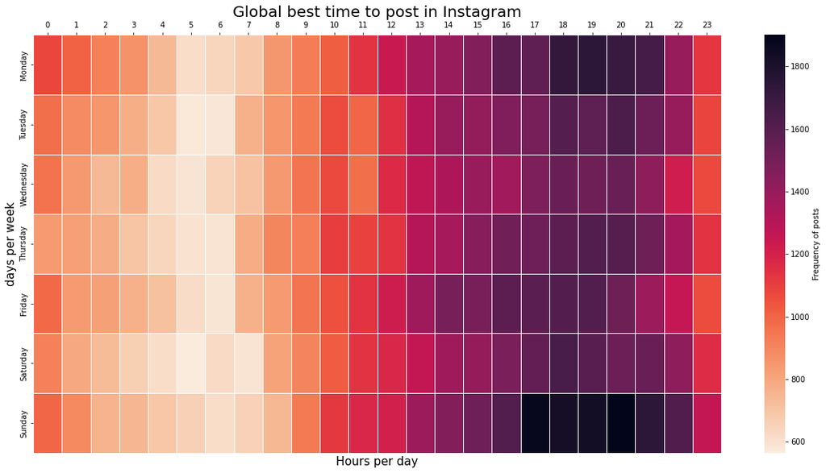

```python
#Plot to see frequency of posts in which hour of the day in a week.

##Seting the size of the plot
plt.rcParams["figure.figsize"] = 20, 10

## heatmap plot for frquency of post per week
ax = sns.heatmap(active_user_hours,  linewidth=0.5, cmap = "rocket_r", cbar_kws={'label': 'Frequency of posts'})

#setting labels for title, xlabel, ylable
plt.title("Global best time to post in Instagram", fontsize=20 )
plt.xlabel("Hours per day",  fontsize = 15)
plt.ylabel("days per week",  fontsize = 15)

#setting xaxis ticks on the top of figure
ax.xaxis.tick_top()
```

In this analysis we have made a heat map of all the posts that were made in the dataset to understand how does the distribution of posting times look like. We can derive a lot of observations and inferences from this observation.

This again is an inference question. Do you want to compete in the completion on a high engagement times or do you want to play safe and avoid competition on low engagement types and win your users. If I were a yoga and meditation startup it would be wise to not post with the competition on tough days and post in the mornings when you can find most relevant customers.

reference: https://statusbrew.com/insights/best-time-to-post-on-instagram/

### Analysis 2 - What locations around the globe should the influencers and businesses target that would ensure higher reach and engagement of the instagram posts?

- To find out the locations with the highest post density we are using kepler.Gl library and ploting the latitude and longitude which are associated with the post. The Kepler.gl is a powerful open source geospatial analysis tool for large-scale data sets. By using this plot we can determine the most popular posting location that a small business/ brand can focus on for thier marketing campaigns.
- To determine this we have merged the instagram_location dataset and instagram_post dataset and considered four columns id,city,lng,lat to a new dataset and for this dataset we have done some configuration settings of mapstyle, mapstate and added data to the map and displayed it. As kepler library provided configuration settings to select the layer and filters. In layers we have selected heatmap to display and analyse the locations of majority of post.

```python
#Ploting number of posts as per location

#Merge posts_sample and locations_samples dataframe
Max_post_location = posts_sample.copy()

#Merging instagram posts and locations dataset to a new dataset
#Merging columns location Id, city, latitude and longitude of instagram locations dataset with location Id of instagram post data set
Max_post_location = pd.merge(Max_post_location, locations_sample[["id","city","lng","lat"]], left_on ="location_id", right_on = "id", how = "inner")

#Display dataset
Max_post_location
```

|  | sid | sid_profile | post_id | profile_id | location_id | cts | post_type | description | numbr_likes | number_comments | hours | days | id | city | lng | lat |
| --- | --- | --- | --- | --- | --- | --- | --- | --- | --- | --- | --- | --- | --- | --- | --- | --- |
| 0 | 15131935 | 3471655 | Bw4XLtMga2j | 358298091 | 548438207 | 2019-04-30 15:03:13 | 1 | Tampa Police Honor Guard was able to join the ... | 206 | 5 | 15 | Tuesday | 548438207 | Madison, Florida | 30.431447 | -83.464751 |
| 1 | 27386281 | 3398819 | BgkKMt4hAW7 | 2955286544 | 1012854533 | 2018-03-21 01:22:38 | 1 | Доброе утро, красотки 💃🏻\nУ нас отличная новос... | 302 | 13983 | 1 | Wednesday | 1012854533 | Vladivostok, Russia | 43.144180 | 131.926630 |
| 2 | 27386295 | 3398819 | BqLfnHeBp_g | 2955286544 | 1012854533 | 2018-11-15 00:42:40 | 1 | Доброе утро, друзья!\nМы запускаем грандиозную... | 113 | 3 | 0 | Thursday | 1012854533 | Vladivostok, Russia | 43.144180 | 131.926630 |
| 3 | 27386298 | 3398819 | Bnm3n-xgvVO | 2955286544 | 1012854533 | 2018-09-12 03:18:44 | 2 | Всем привет🌷\nСегодня самый важный день для на... | 63 | 4 | 3 | Wednesday | 1012854533 | Vladivostok, Russia | 43.144180 | 131.926630 |
| 4 | 27386293 | 3398819 | BqqRzM_BRz6 | 2955286544 | 1012854533 | 2018-11-26 23:38:26 | 1 | Доброе утро 🌷\nФакты о яркой и насыщенной пома... | 73 | 0 | 23 | Monday | 1012854533 | Vladivostok, Russia | 43.144180 | 131.926630 |
| ... | ... | ... | ... | ... | ... | ... | ... | ... | ... | ... | ... | ... | ... | ... | ... | ... |
| 99657 | 28359019 | 383372 | BY3QCbqFapy | 636604855 | 1027078477 | 2017-09-10 16:08:05 | 1 | Organic architecture seeks superior sense of u... | 123 | 9 | 16 | Sunday | 1027078477 | Bentonville, Arkansas | 36.381078 | -94.203880 |
| 99658 | 28362915 | 3352354 | BVzbCWNAmjv | 641335287 | 11842063 | 2017-06-26 14:53:02 | 1 | oh we all do love a good dramatic side profile... | 165 | 1 | 14 | Monday | 11842063 | Chorley | 53.653170 | -2.633765 |
| 99659 | 28365517 | 3465789 | ByAWdkPBohX | 3253277211 | 1746599282054295 | 2019-05-28 14:02:44 | 2 | Что делать, чтоб ребенок произносил слова полн... | 532 | 30 | 14 | Tuesday | 1746599282054295 | Sevastopol, Ukraine | 44.586225 | 33.461280 |
| 99660 | 28365554 | 3465789 | ByE7QE9Cigy | 3253277211 | 1746599282054295 | 2019-05-30 08:40:40 | 1 | Не ожидала, что Костя справится!\n❤ трудяге 👩🏻... | 487 | 21 | 8 | Thursday | 1746599282054295 | Sevastopol, Ukraine | 44.586225 | 33.461280 |
| 99661 | 28368403 | 3318868 | Bfy1ESNn9hh | 39487049 | 271831220 | 2018-03-01 21:35:12 | 1 | Laughing our way through act I! \nWearing @coa... | 376 | 5 | 21 | Thursday | 271831220 | Wallasey | 53.439963 | -3.039243 |

99662 rows × 16 columns

```python
#Load a map with location data of maximum posts on instagram
map_1 = KeplerGl(height=600)

#cosidering the city, latitude and logitude parameterts to display on map
Max_post_location =  pd.DataFrame({'Loc_id' : Max_post_location.city,
                'Latitude': Max_post_location.lng,
            'Longitude': Max_post_location.lat})

#Add data to the map
map_1.add_data(data=Max_post_location, name='posts_location')

custom_config = {
  #"version": "v1",
  "config": {
    "visState": {
      "filters": [],
      "layers": []

    },
    "mapState": {
      "bearing": -4.928571428571431,
      "dragRotate": True,
      #"latitude": 52.253971373306165,
      #"longitude": -2.6899063817571394,
      #"pitch": 49.18440507924836,
      "zoom": 60.655984704565685,
      "isSplit": False
    },
    "mapStyle": {
      "styleType": "",
      "topLayerGroups": {},
      "visibleLayerGroups": {
        "label": False,
        "road": False,
        "border": False,
        "building": False,
        "water": True,
        "land": True
      }
    }

  } }
map_1 = KeplerGl(
    height=800,
    data={'data_1': Max_post_location},
    config=custom_config
)

map_1
```

```
User Guide: https://docs.kepler.gl/docs/keplergl-jupyter
User Guide: https://docs.kepler.gl/docs/keplergl-jupyter
```

```
KeplerGl(config={'config': {'visState': {'filters': [], 'layers': []}, 'mapState': {'bearing': -4.928571428571…
```

- Looking at the Keplers map we can clearly observe that globally, most traffic is generated from European countries. The map shows highest density around United Kindom, France, Italy, Switzerland and some traffic around Spain.
- Followed by that, North America has the highest traffic. Most of the traffic is concentrated around the United States of America. The highest post traffic is concentrated around eastern coast of the USA with majority traffic coming from New York and Miami and some traffic from San Diego and San Francisco.

### Analysis 3 - Good User Vs Bad User

First lets analyze the top 10 profiles with the best quality score and the low 10 profiles with the worst quality score to understand.

```python
## Get Top 10 profiles with the best quality score
df_quality_score_grade.sort_values(by=['overall_score'], ascending=False, inplace=True)

df_quality_score_grade.head(10)
```

| profile_id | n_posts | followers | eng_score | eng_score_rec | perc_inc_eng_score | avg_likes_by_foll | avg_com_by_foll | hashtag_score | bio_with_keyword | posts_with_keyword | posts_with_keyword_by_total | hashtag_with_keyword | eng_score_keyword | overall_score | quality_score (in %) | quality_score (percentile_rank) |
| --- | --- | --- | --- | --- | --- | --- | --- | --- | --- | --- | --- | --- | --- | --- | --- | --- |
| 229891512 | 1.75 | 11.64 | 27.70 | 7.45 | 0.01 | 16.43 | 0.61 | 50.3 | 0.0 | 63.16 | 97.0 | 35.20 | 100.00 | 3860.675 | 100.00 | 1.0 |
| 5314861065 | 0.28 | 1.23 | 100.00 | 100.00 | 3.50 | 69.29 | 100.00 | 88.3 | 0.0 | 0.00 | 0.0 | 0.00 | 0.00 | 3783.750 | 98.01 | 1.0 |
| 1160289453 | 4.17 | 1.12 | 9.25 | 1.37 | 0.07 | 2.86 | 0.00 | 54.9 | 100.0 | 100.00 | 85.0 | 18.69 | 29.11 | 3250.750 | 84.20 | 1.0 |
| 246434700 | 5.07 | 1.02 | 4.11 | 1.04 | 0.29 | 1.43 | 0.00 | 74.5 | 0.0 | 77.19 | 73.0 | 100.00 | 12.54 | 3128.050 | 81.02 | 1.0 |
| 9293314310 | 0.50 | 1.02 | 8.06 | 6.60 | 0.13 | 12.14 | 1.23 | 74.6 | 100.0 | 22.81 | 100.0 | 45.79 | 29.70 | 3104.950 | 80.43 | 1.0 |
| 7499301002 | 0.42 | 1.59 | 10.47 | 9.30 | 0.78 | 18.57 | 0.61 | 90.8 | 100.0 | 15.79 | 75.0 | 19.31 | 29.11 | 2789.175 | 72.25 | 1.0 |
| 249060769 | 0.21 | 1.27 | 8.25 | 5.69 | 0.06 | 10.71 | 3.07 | 54.6 | 100.0 | 21.05 | 92.0 | 41.74 | 26.15 | 2784.500 | 72.12 | 1.0 |
| 3168768346 | 1.72 | 4.39 | 4.69 | 4.00 | 0.00 | 7.86 | 0.61 | 85.0 | 100.0 | 21.05 | 100.0 | 18.69 | 17.28 | 2670.700 | 69.18 | 1.0 |
| 253648 | 2.05 | 1.81 | 5.81 | 4.62 | 0.06 | 10.71 | 0.00 | 73.3 | 100.0 | 21.05 | 100.0 | 16.51 | 21.42 | 2632.100 | 68.18 | 1.0 |
| 1081823452 | 0.53 | 1.31 | 9.47 | 7.35 | 0.13 | 15.71 | 0.61 | 75.4 | 100.0 | 17.54 | 77.0 | 10.59 | 27.69 | 2548.450 | 66.01 | 1.0 |

Profile of the top quality score user:

[figure not shown]

```python
## Get Lowest 10 profiles with the worst quality score
df_quality_score_grade.sort_values(by=['overall_score'], ascending=True, inplace=True)

df_quality_score_grade.head(10)
```

| profile_id | n_posts | followers | eng_score | eng_score_rec | perc_inc_eng_score | avg_likes_by_foll | avg_com_by_foll | hashtag_score | bio_with_keyword | posts_with_keyword | posts_with_keyword_by_total | hashtag_with_keyword | eng_score_keyword | overall_score | quality_score (in %) | quality_score (percentile_rank) |
| --- | --- | --- | --- | --- | --- | --- | --- | --- | --- | --- | --- | --- | --- | --- | --- | --- |
| 11691660583 | 0.00 | 1.06 | 0.00 | 0.00 | 0.00 | 0.00 | 0.0 | 0.0 | 0.0 | 0.0 | 0.0 | 0.0 | 0.0 | 5.300 | 0.14 | 0.0 |
| 10877462526 | 0.05 | 1.01 | 0.03 | 0.03 | 0.09 | 0.00 | 0.0 | 0.0 | 0.0 | 0.0 | 0.0 | 0.0 | 0.0 | 6.425 | 0.17 | 0.0 |
| 814440460 | 0.05 | 1.12 | 0.03 | 0.03 | 0.00 | 0.00 | 0.0 | 0.0 | 0.0 | 0.0 | 0.0 | 0.0 | 0.0 | 6.525 | 0.17 | 0.0 |
| 339574882 | 0.00 | 1.47 | 0.00 | 0.00 | 0.00 | 0.00 | 0.0 | 0.0 | 0.0 | 0.0 | 0.0 | 0.0 | 0.0 | 7.350 | 0.19 | 0.0 |
| 486817070 | 0.11 | 1.04 | 0.10 | 0.07 | 0.32 | 0.00 | 0.0 | 0.0 | 0.0 | 0.0 | 0.0 | 0.0 | 0.0 | 9.225 | 0.24 | 0.0 |
| 2223667168 | 0.01 | 1.03 | 0.13 | 0.13 | 0.00 | 0.71 | 0.0 | 0.0 | 0.0 | 0.0 | 0.0 | 0.0 | 0.0 | 11.675 | 0.30 | 0.0 |
| 11225411683 | 0.00 | 1.51 | 0.03 | 0.03 | 0.00 | 0.71 | 0.0 | 0.0 | 0.0 | 0.0 | 0.0 | 0.0 | 0.0 | 11.775 | 0.30 | 0.0 |
| 2463251494 | 1.04 | 1.07 | 0.10 | 0.10 | 0.04 | 0.00 | 0.0 | 0.0 | 0.0 | 0.0 | 0.0 | 0.0 | 0.0 | 13.000 | 0.34 | 0.0 |
| 287308351 | 0.29 | 1.64 | 0.16 | 0.13 | 0.18 | 0.00 | 0.0 | 0.0 | 0.0 | 0.0 | 0.0 | 0.0 | 0.0 | 13.775 | 0.36 | 0.0 |
| 4485941416 | 0.39 | 1.07 | 0.13 | 0.10 | 0.90 | 0.00 | 0.0 | 0.0 | 0.0 | 0.0 | 0.0 | 0.0 | 0.0 | 14.350 | 0.37 | 0.0 |

Profile with the worst quality score:

[figure not shown]

In this analysis we used the keyword “travel” and calculated the quality score of all the users im the dataset. We found the good user with a quality score of 100% and bad user with a quality score of 0.14 percent.

- After calculating the score for all users we can observe a clear contrast between both the profiles in various matrix.
- We can clearly inter from this that not just engagement but so many other matrix have a major role to play while judging a user’s quality.
- Another observation from the analysis would be that there are both static and dynamic matrix to consider while judging a user.
- we can infer from this that it’s not just the static matrix like likes, followers, posts etc that play a role in judging the user. To find the most appropriate user for the requirement we need to consider metrix that are specific to the requirement by giving a required keyword.

## Conclusion

With better utilization of all variables from the static data, we can create a formula that genuinely considers every aspect of a user's profile and judge them precisely to the requirements of a business.

This model can be enhanced with the availability of real-time data and user analytics report of the users.

The future scope for this project would be to work on universal data of the platform and perform real-time analysis on all the new time series metrics like stories, highlights, reels, etc.

```
"I pledge on my honor that I have not given nor received any unauthorized assistance on this assignment."
```